# Overall CFS Semantics Analysis

Hugh Rabagliati

11 December 2016

# 1 Background

Sklar et al (2012) reports a series of studies that use “breaking continuous flash suppression” to suggest that participants are faster to become aware of sentences if they have unusual semantics.

In these experiments, we set out to replicate these effects. We also replicate work by Yang & Yeh (2011) who demonstrated that suppression times are longer for words with unusual semantics.

In Experiments 1 and 2, we replicated Sklar et al’s Experiments 1 and 2, using English versions of their materials, and extending their manipulations to provide a better-controlled test. In Experiment 3, we replicates Experiments 1 and 2 using their original presentation scripts. In Experiment 4, we replicate some of the conditions in Yang and Yeh’s Experiment 1.

# 2 Experiment 1

In this study, we compare suppression times for semantically anomalous versus neutral sentences. In the original study, the authors only examined raw RTs, but as shown below, these were highly skewed. We therefore examine both raw and log transformed RTs.

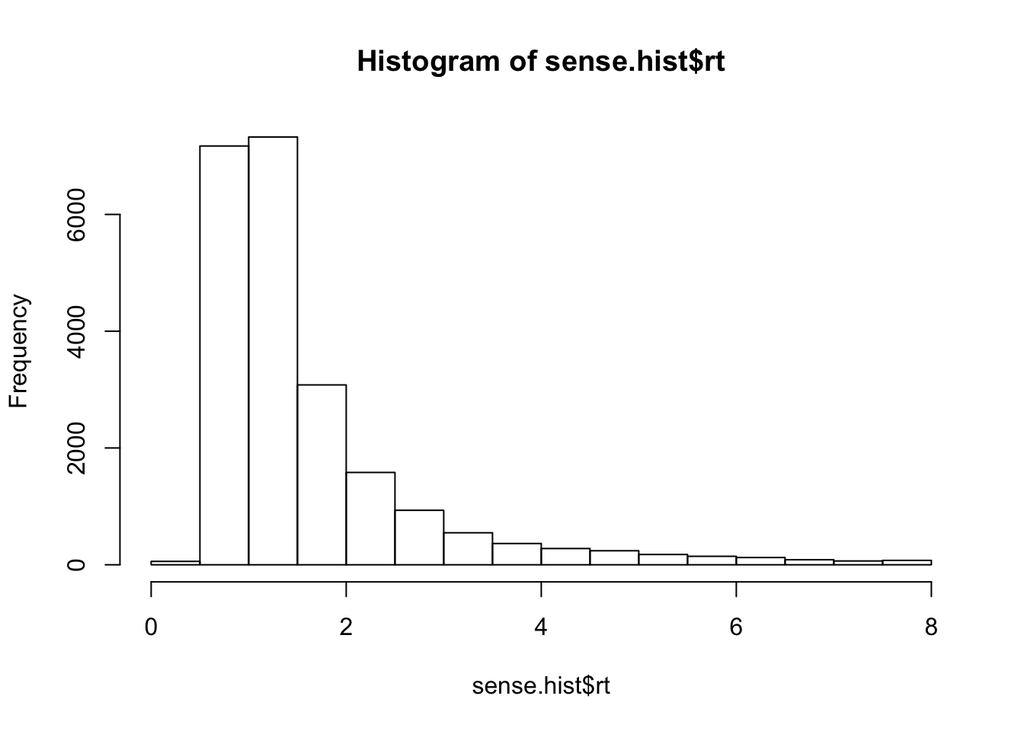

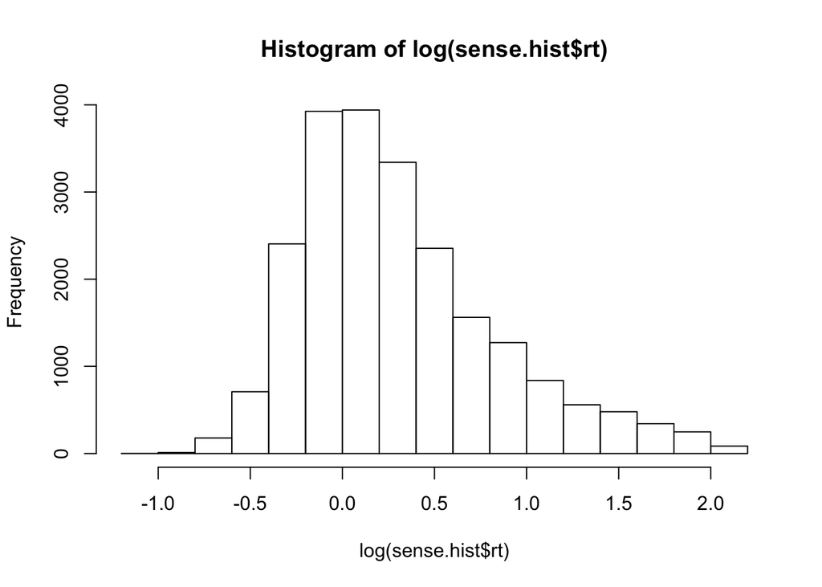

## 2.1 Experiment 1a

### 2.1.1 Raw RTs

There is a marginal effect of semantics for Raw RTs for Experiment 1a

```
## [1] 2.522797
```

```r
# excluded subjects
print(paste("n subj excluded = ",total.n-excl.n))
```

```
## [1] "n subj excluded =  5"
```

```r
# excluded trials
print(paste("% trials excluded= ",((n.trials - n.excl.trials)/n.trials)*100))
```

```
## [1] "% trials excluded=  6.39982876712329"
```

```r
print(paste("median trials excluded per participant = ",median(subj.excl.trials$final_trials), "sd= ", sd(subj.excl.trials$final_trials), "range= ", c(range(subj.excl.trials$final_trials))))
```

```
## [1] "median trials excluded per participant =  5 sd=  4.45898368027883 range=  1"
## [2] "median trials excluded per participant =  5 sd=  4.45898368027883 range=  20"
```

```r
print(paste("median timeouts per participant = ",median(timeouts$rt), "sd= ", sd(timeouts$rt), "range= ", range(timeouts$rt)))
```

```
## [1] "median timeouts per participant =  0 sd=  9.01019419432503 range=  0"
## [2] "median timeouts per participant =  0 sd=  9.01019419432503 range=  44"
```

```r
# Standardize lenth
sense.pop.sklar$Length <- (sense.pop.sklar$Length - mean(sense.pop.sklar$Length, na.rm = T))/sd(sense.pop.sklar$Length, na.rm = T)


# T test (Sklar style)
sense.pop.sklar.summary <- summaryBy(rt + perceptual.rating~ SubjNo + Condition, data = subset(sense.pop.sklar,  Condition %in% c("Sklar_violation", "Sklar_control")), keep.names = T)
kable(summaryBy(rt*1000 + perceptual.rating~ Condition, data = sense.pop.sklar.summary, FUN = c(mean,sd)), digits = 2)
```

| Condition | rt * 1000.mean | perceptual.rating.mean | rt * 1000.sd | perceptual.rating.sd |
| --- | --- | --- | --- | --- |
| Sklar_control | 1466.33 | 1.86 | 504.79 | 0.49 |
| Sklar_violation | 1501.53 | 1.81 | 566.91 | 0.50 |

```r
t.test(rt ~ Condition, data = sense.pop.sklar.summary, paired = T)
```

```
##
##  Paired t-test
##
## data:  rt by Condition
## t = -1.7874, df = 47, p-value = 0.08033
## alternative hypothesis: true difference in means is not equal to 0
## 95 percent confidence interval:
##  -0.074811818  0.004418131
## sample estimates:
## mean of the differences
##             -0.03519684
```

```r
t.test(perceptual.rating ~ Condition, data = sense.pop.sklar.summary, paired = T)
```

```
##
##  Paired t-test
##
## data:  perceptual.rating by Condition
## t = 2.7847, df = 47, p-value = 0.007698
## alternative hypothesis: true difference in means is not equal to 0
## 95 percent confidence interval:
##  0.01493408 0.09267209
## sample estimates:
## mean of the differences
##              0.05380309
```

```r
es <- t.test(rt ~ Condition, data = sense.pop.sklar.summary, paired = T)
es.t.test.raw <- data.frame(t = es$statistic,n1 = es$parameter,n2 = es$parameter,
                            r = cor.test(subset(sense.pop.sklar.summary, Condition == "Sklar_control")$rt,subset(sense.pop.sklar.summary, Condition == "Sklar_violation")$rt)$estimate)


# Bayes factor -- minimum effect of 0.01, maximum of 0.06, our effect = -0.03519684 and our SE = -0.03/-1.7874=  0.01678416

# lmer (Rabag style)
sense.pop.sklar.raw <- summary(lmer(rt ~ Condition+Length + (1+Condition|SubjNo)+ (1|prime), data = subset(sense.pop.sklar,  Condition %in% c("Sklar_violation", "Sklar_control"))))
kable(data.frame(sense.pop.sklar.raw$coefficients,"p value"= 2*pnorm(-abs(coef(sense.pop.sklar.raw)[,3]))), digit =2)
```

|  | Estimate | Std..Error | t.value | p.value |
| --- | --- | --- | --- | --- |
| (Intercept) | 1.47 | 0.07 | 20.07 | 0.00 |
| ConditionSklar_violation | 0.03 | 0.02 | 1.48 | 0.14 |
| Length | -0.04 | 0.01 | -4.29 | 0.00 |

```r
#print(paste("p value = ", 2*pnorm(-abs(coef(sense.pop.sklar.raw)[,3]))))
```

### 2.1.2 Log RTs

There is no effect of semantics for Log RTs for Experiment 1a

```
## [1] 0.9092276
```

```r
# Standardize lenth
sense.pop.sklar$Length <- (sense.pop.sklar$Length - mean(sense.pop.sklar$Length, na.rm = T))/sd(sense.pop.sklar$Length, na.rm = T)


# T test (Sklar style)
sense.pop.sklar.summary <- summaryBy(rt~ SubjNo + Condition, data = subset(sense.pop.sklar,  Condition %in% c("Sklar_violation", "Sklar_control")), keep.names = T)
kable(summaryBy(rt ~ Condition, data = sense.pop.sklar.summary, FUN = c(mean,sd)), digits =2)
```

| Condition | rt.mean | rt.sd |
| --- | --- | --- |
| Sklar_control | 7.21 | 0.36 |
| Sklar_violation | 7.23 | 0.38 |

```r
t.test(rt ~ Condition, data = sense.pop.sklar.summary, paired = T)
```

```
##
##  Paired t-test
##
## data:  rt by Condition
## t = -1.2248, df = 47, p-value = 0.2267
## alternative hypothesis: true difference in means is not equal to 0
## 95 percent confidence interval:
##  -0.039696479  0.009651483
## sample estimates:
## mean of the differences
##              -0.0150225
```

```r
es <- t.test(rt ~ Condition, data = sense.pop.sklar.summary, paired = T)
es.t.test.log <- data.frame(t = es$statistic,n1 = es$parameter,n2 = es$parameter,
                            r = cor.test(subset(sense.pop.sklar.summary, Condition == "Sklar_control")$rt,subset(sense.pop.sklar.summary, Condition == "Sklar_violation")$rt)$estimate)

# Bayes factor -- minimum effect of 0.01, maximum of 0.06, our effect = -0.03519684 and our SE = -0.03/-1.7874=  0.01678416
# Bayes factor -- minimum effect of 0.01, maximum of 0.06, our effect = -0.03519684 and our SE = -0.03/-1.7874=  0.01678416

# lmer (Rabag style)
sense.pop.sklar.log <- summary(lmer(rt ~ Condition +Length+ (1+Condition|SubjNo)+ (1|prime), data = subset(sense.pop.sklar,  Condition %in% c("Sklar_violation", "Sklar_control"))))
kable(data.frame(sense.pop.sklar.log$coefficients, "p value" = 2*pnorm(-abs(coef(sense.pop.sklar.log)[,3]))), digits = 2)
```

|  | Estimate | Std..Error | t.value | p.value |
| --- | --- | --- | --- | --- |
| (Intercept) | 7.21 | 0.05 | 139.79 | 0.00 |
| ConditionSklar_violation | 0.01 | 0.01 | 1.02 | 0.31 |
| Length | -0.03 | 0.01 | -4.78 | 0.00 |

```r
#print(paste("p value = ", 2*pnorm(-abs(coef(sense.pop.sklar.log)[,3]))))

# Analysis of PAS
# sense.pop.sklar.log.pas <- summary(lmer(rt ~ Condition * perceptual.rating +Length+ (1+Condition|SubjNo)+ (1|prime), data = subset(sense.pop.sklar,  Condition %in% c("Sklar_violation", "Sklar_control"))))
# print(sense.pop.sklar.log.pas)
#
# sense.pop.sklar.log.pas2 <- summary(lmer(perceptual.rating ~ Condition +Length+ (1+Condition|SubjNo)+ (1|prime), data = subset(sense.pop.sklar,  Condition %in% c("Sklar_violation", "Sklar_control"))))
# print(sense.pop.sklar.log.pas2)
```

## 2.2 Experiment 1b

### 2.2.1 Raw RTs

There is no effect of semantics for Raw RTs for Experiment 1b

```r
# excluded subjects
print(paste("n subj excluded = ",total.n-excl.n))
```

```
## [1] "n subj excluded =  5"
```

```r
# excluded trials
print(paste("% trials excluded = ",((n.trials - n.excl.trials)/n.trials)*100))
```

```
## [1] "% trials excluded =  6.31267585311305"
```

```r
print(paste("median trials excluded per participant = ",median(subj.excl.trials$final_trials), "sd= ", sd(subj.excl.trials$final_trials), "range= ", range(subj.excl.trials$final_trials)))
```

```
## [1] "median trials excluded per participant =  12.5 sd=  13.6026273797089 range=  2"
## [2] "median trials excluded per participant =  12.5 sd=  13.6026273797089 range=  59"
```

```r
print(paste("median timeouts per participant = ",median(timeouts$rt), "sd= ", sd(timeouts$rt), "range= ", range(timeouts$rt)))
```

```
## [1] "median timeouts per participant =  1 sd=  23.5189143534677 range=  0"
## [2] "median timeouts per participant =  1 sd=  23.5189143534677 range=  119"
```

```r
# Standardize lenth


# Standardize lenth
sense.pop.new$Length <- (sense.pop.new$Length - mean(sense.pop.new$Length, na.rm = T))/sd(sense.pop.new$Length, na.rm = T)

# T test (Sklar style)
sense.pop.new.summary <- summaryBy(rt + perceptual.rating~ SubjNo + Condition, data = subset(sense.pop.new,  Condition %in% c("Non-sensible","Sensible")), keep.names = T)
kable(summaryBy(rt*1000+ perceptual.rating ~ Condition, data = sense.pop.new.summary, FUN = c(mean,sd)), digits = 2)
```

| Condition | rt * 1000.mean | perceptual.rating.mean | rt * 1000.sd | perceptual.rating.sd |
| --- | --- | --- | --- | --- |
| Non-sensible | 1463.25 | 1.84 | 549.85 | 0.5 |
| Sensible | 1463.48 | 1.84 | 535.59 | 0.5 |

```r
t.test(rt ~ Condition, data = sense.pop.new.summary, paired = T)
```

```
##
##  Paired t-test
##
## data:  rt by Condition
## t = -0.02217, df = 47, p-value = 0.9824
## alternative hypothesis: true difference in means is not equal to 0
## 95 percent confidence interval:
##  -0.02135123  0.02088578
## sample estimates:
## mean of the differences
##           -0.0002327283
```

```r
t.test(perceptual.rating ~ Condition, data = sense.pop.new.summary, paired = T)
```

```
##
##  Paired t-test
##
## data:  perceptual.rating by Condition
## t = 0.24623, df = 47, p-value = 0.8066
## alternative hypothesis: true difference in means is not equal to 0
## 95 percent confidence interval:
##  -0.02056688  0.02630377
## sample estimates:
## mean of the differences
##             0.002868449
```

```r
es <- t.test(rt ~ Condition, data = sense.pop.new.summary, paired = T)

es.t.test.raw <- rbind(es.t.test.raw, data.frame(t = es$statistic,n1 = es$parameter,n2 = es$parameter,
                            r = cor.test(subset(sense.pop.new.summary, Condition == "Non-sensible")$rt,subset(sense.pop.new.summary, Condition == "Sensible")$rt)$estimate))

# Bayes factor -- minimum effect of 0.01, maximum of 0.06, our effect = -0.0002327283 and our SE = -0.03/-0.02217=  0.01049744


# lmer (rabag style)
sense.pop.new.raw <-summary(lmer(rt ~ Condition+Length + (1+Condition|SubjNo)+ (1|prime), data = subset(sense.pop.new,  Condition %in% c("Non-sensible","Sensible"))))
kable(data.frame(sense.pop.new.raw$coefficients, "p value" = 2*pnorm(-abs(coef(sense.pop.new.raw)[,3]))), digits = 2)
```

|  | Estimate | Std..Error | t.value | p.value |
| --- | --- | --- | --- | --- |
| (Intercept) | 1.46 | 0.08 | 18.49 | 0.00 |
| ConditionSensible | 0.00 | 0.01 | 0.36 | 0.72 |
| Length | -0.02 | 0.01 | -3.43 | 0.00 |

```r
#print(paste("p value = ", 2*pnorm(-abs(coef(sense.pop.new.raw)[,3]))))
```

### 2.2.2 Log RTs

There is no effect of semantics for Log RTs for Experiment 1b

```r
# Standardize lenth
sense.pop.new$Length <- (sense.pop.new$Length - mean(sense.pop.new$Length, na.rm = T))/sd(sense.pop.new$Length, na.rm = T)

# T test (Sklar style)
sense.pop.new.summary <- summaryBy(rt ~ SubjNo + Condition, data = subset(sense.pop.new,  Condition %in% c("Non-sensible","Sensible")), keep.names = T)
kable(summaryBy(rt ~ Condition, data = sense.pop.new.summary, FUN = c(mean,sd)), digits =2 )
```

| Condition | rt.mean | rt.sd |
| --- | --- | --- |
| Non-sensible | 7.2 | 0.37 |
| Sensible | 7.2 | 0.37 |

```r
t.test(rt ~ Condition, data = sense.pop.new.summary, paired = T)
```

```
##
##  Paired t-test
##
## data:  rt by Condition
## t = -0.8643, df = 47, p-value = 0.3918
## alternative hypothesis: true difference in means is not equal to 0
## 95 percent confidence interval:
##  -0.016742376  0.006679635
## sample estimates:
## mean of the differences
##             -0.00503137
```

```r
es <- t.test(rt ~ Condition, data = sense.pop.new.summary, paired = T)

es.t.test.log <- rbind(es.t.test.log, data.frame(t = es$statistic,n1 = es$parameter,n2 = es$parameter,
                            r = cor.test(subset(sense.pop.new.summary, Condition == "Non-sensible")$rt,subset(sense.pop.new.summary, Condition == "Sensible")$rt)$estimate))
# Bayes factor -- minimum effect of 0.01, maximum of 0.06, our effect = -0.0002327283 and our SE = -0.03/-0.02217=  0.01049744


# lmer (rabag style)
sense.pop.new.log <-summary(lmer(rt ~ Condition +Length+ (1+Condition|SubjNo)+ (1|prime), data = subset(sense.pop.new,  Condition %in% c("Non-sensible","Sensible"))))
kable(data.frame(sense.pop.new.log$coefficients, "p value" = 2*pnorm(-abs(coef(sense.pop.new.log)[,3]))), digits = 2)
```

|  | Estimate | Std..Error | t.value | p.value |
| --- | --- | --- | --- | --- |
| (Intercept) | 7.20 | 0.05 | 133.18 | 0.00 |
| ConditionSensible | 0.01 | 0.01 | 0.80 | 0.42 |
| Length | -0.01 | 0.00 | -2.79 | 0.01 |

```r
#print(paste("p value = ", 2*pnorm(-abs(coef(sense.pop.new.log)[,3]))))

# Analysis of PAS
# sense.pop.new.log.pas <- summary(lmer(rt ~ Condition * perceptual.rating +Length+ (1+Condition|SubjNo)+ (1|prime), data = subset(sense.pop.new,  Condition %in% c("Non-sensible","Sensible"))))
# print(sense.pop.new.log.pas)
#
# sense.pop.new.log.pas2 <- summary(lmer(perceptual.rating ~ Condition +Length+ (1+Condition|SubjNo)+ (1|prime), data = subset(sense.pop.new,  Condition %in% c("Non-sensible","Sensible"))))
# print(sense.pop.new.log.pas2)
```

## 2.3 Experiment 1 Length analysis

RTs are faster for longer stims for raw data

```r
sense.pop.length.raw <- summary(lmer(rt ~ Length + (1+Length|SubjNo), data = sense.pop.length))
kable(data.frame(sense.pop.length.raw$coefficients, "p value" = 2*pnorm(-abs(coef(sense.pop.length.raw)[,3]))), digits = 2)
```

|  | Estimate | Std..Error | t.value | p.value |
| --- | --- | --- | --- | --- |
| (Intercept) | 1.58 | 0.10 | 15.75 | 0 |
| Length | -0.02 | 0.01 | -3.15 | 0 |

```r
#print(paste("p value = ", 2*pnorm(-abs(coef(sense.pop.length.raw)[,3]))))
```

RTs are faster for longer stims for log data.

```r
sense.pop.length.log <- summary(lmer(rt ~ Length + (1+Length|SubjNo), data = sense.pop.length))
kable(data.frame(sense.pop.length.log$coefficients, "p value"=2*pnorm(-abs(coef(sense.pop.length.log)[,3]))), digits = 2)
```

|  | Estimate | Std..Error | t.value | p.value |
| --- | --- | --- | --- | --- |
| (Intercept) | 0.31 | 0.06 | 5.67 | 0 |
| Length | -0.02 | 0.00 | -4.58 | 0 |

```r
#print(paste("p value = ", 2*pnorm(-abs(coef(sense.pop.length.log)[,3]))))
```

## 2.4 Graphs

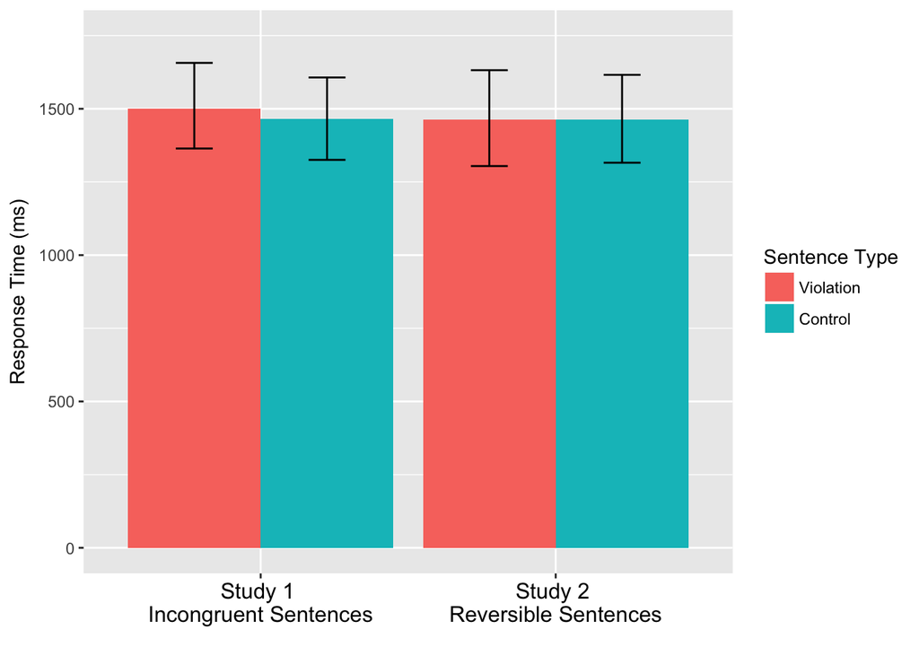

# 3 Experiment 2

In this experiment, we assess the emotional studies of Sklar et al (Experiment 4).

## 3.1 Experiment 2a

### 3.1.1 Raw RTs

Semantics has no effect for raw RTs

```r
# excluded subjects
print(paste("n subj excluded = ",total.n-excl.n))
```

```
## [1] "n subj excluded =  3"
```

```r
# excluded trials
print(paste("% trials excluded = ",((n.trials - n.excl.trials)/n.trials)*100))
```

```
## [1] "% trials excluded =  3.40076223981237"
```

```r
print(paste("median trials excluded per participant = ",median(subj.excl.trials$rt), "sd= ", sd(subj.excl.trials$final_trials), "range= ", range(subj.excl.trials$final_trials)))
```

```
## [1] "median trials excluded per participant =  2 sd=  1.30645792053807 range=  0"
## [2] "median trials excluded per participant =  2 sd=  1.30645792053807 range=  6"
```

```r
print(paste("median timeouts per participant = ",median(timeouts$rt), "sd= ", sd(timeouts$rt), "range= ", range(timeouts$rt)))
```

```
## [1] "median timeouts per participant =  0 sd=  3.57172644985199 range=  0"
## [2] "median timeouts per participant =  0 sd=  3.57172644985199 range=  22"
```

```r
# Standardize lenth

# Standardize lenth
emo.pop.sklar$Length <- (emo.pop.sklar$Length - mean(emo.pop.sklar$Length, na.rm = T))/sd(emo.pop.sklar$Length, na.rm = T)

# Lin Reg (sklar style)
emo.pop.sklar.sum <- summaryBy(rt +perceptual.rating ~ prime + MeanAffectivity, data = emo.pop.sklar, keep.names = T)
emo.pop.sklar.sum.graph <- emo.pop.sklar.sum
print("Affective Valence against RT")
```

```
## [1] "Affective Valence against RT"
```

```r
kable(summary(lm(rt ~ MeanAffectivity, data = emo.pop.sklar.sum))$coefficients,digits=2)
```

|  | Estimate | Std. Error | t value | Pr(>\|t\|) |
| --- | --- | --- | --- | --- |
| (Intercept) | 1.53 | 0.01 | 123.63 | 0.00 |
| MeanAffectivity | -0.02 | 0.01 | -1.51 | 0.14 |

```r
print("Affective Valence against Rating Scale")
```

```
## [1] "Affective Valence against Rating Scale"
```

```r
kable(summary(lm(perceptual.rating ~ MeanAffectivity, data = emo.pop.sklar.sum))$coefficients,digits=2)
```

|  | Estimate | Std. Error | t value | Pr(>\|t\|) |
| --- | --- | --- | --- | --- |
| (Intercept) | 1.99 | 0.01 | 144.13 | 0.00 |
| MeanAffectivity | -0.01 | 0.01 | -0.54 | 0.59 |

```r
es <- lm(rt~MeanAffectivity, data = emo.pop.sklar.sum)
es.t.test.raw <- rbind(es.t.test.raw, data.frame(t = summary(es)$coefficients[2,3],n1 = summary(es)$df[2],
                                                 n2 = summary(es)$df[2],
                                                 r = 0.5))
# note that r = 0.5 here because it is not a within subjects test


# lmer (rabag style)
emo.sklar.lmer.raw <- summary(lmer(rt ~ MeanAffectivity+Length + (1+MeanAffectivity|SubjNo)+ (1|prime), data = subset(emo.pop.sklar, prime_semantics %in% c("Negative phrase","Neutral phrase"))))
print("Affective Valence against RT")
```

```
## [1] "Affective Valence against RT"
```

```r
kable(data.frame(emo.sklar.lmer.raw$coefficients, "p value"=2*pnorm(-abs(coef(emo.sklar.lmer.raw)[,3]))), digits =2 )
```

|  | Estimate | Std..Error | t.value | p.value |
| --- | --- | --- | --- | --- |
| (Intercept) | 1.56 | 0.08 | 20.67 | 0.00 |
| MeanAffectivity | -0.02 | 0.01 | -1.90 | 0.06 |
| Length | -0.03 | 0.01 | -2.07 | 0.04 |

```r
#print(paste("p value = ", 2*pnorm(-abs(coef(emo.sklar.lmer.raw)[,3]))))
```

### 3.1.2 log RTs

For Experiment 2a, semantics has no effect for log RTs

```r
# Standardize lenth
emo.pop.sklar$Length <- (emo.pop.sklar$Length - mean(emo.pop.sklar$Length, na.rm = T))/sd(emo.pop.sklar$Length, na.rm = T)


# Lin Reg (sklar style)
emo.pop.sklar.sum <- summaryBy(rt ~ prime + MeanAffectivity, data = emo.pop.sklar, keep.names = T)
print("Valence against RT")
```

```
## [1] "Valence against RT"
```

```r
kable(summary(lm(rt ~ MeanAffectivity, data = emo.pop.sklar.sum))$coefficients, digits =2)
```

|  | Estimate | Std. Error | t value | Pr(>\|t\|) |
| --- | --- | --- | --- | --- |
| (Intercept) | 0.32 | 0.01 | 47.90 | 0.00 |
| MeanAffectivity | -0.01 | 0.01 | -1.34 | 0.19 |

```r
es <- lm(rt~MeanAffectivity, data = emo.pop.sklar.sum)
es.t.test.log <- rbind(es.t.test.log, data.frame(t = summary(es)$coefficients[2,3],n1 = summary(es)$df[2],
                                                 n2 = summary(es)$df[2],
                                                 r = 0.5))


# lmer (rabag style)
emo.sklar.lmer.log <- summary(lmer(rt ~ MeanAffectivity+Length + (1+MeanAffectivity|SubjNo)+ (1|prime), data = subset(emo.pop.sklar, prime_semantics %in% c("Negative phrase","Neutral phrase"))))
print("Valence against RT")
```

```
## [1] "Valence against RT"
```

```r
kable(data.frame(emo.sklar.lmer.log$coefficients, "p value"=2*pnorm(-abs(coef(emo.sklar.lmer.log)[,3]))), digits =2)
```

|  | Estimate | Std..Error | t.value | p.value |
| --- | --- | --- | --- | --- |
| (Intercept) | 0.33 | 0.04 | 8.03 | 0.00 |
| MeanAffectivity | -0.01 | 0.01 | -1.85 | 0.06 |
| Length | -0.01 | 0.01 | -2.18 | 0.03 |

```r
#print(paste("p value = ", 2*pnorm(-abs(coef(emo.sklar.lmer.log)[,3]))))
#
# # Analysis of PAS
# emo.pop.sklar.log.pas <- summary(lmer(rt ~ MeanAffectivity * perceptual.rating +Length+ (1+Condition|SubjNo)+ (1|prime), subset(emo.pop.sklar, prime_semantics %in% c("Negative phrase","Neutral phrase"))))
# print(emo.pop.sklar.log.pas)
#
# emo.pop.sklar.log.pas2 <- summary(lmer(perceptual.rating ~ MeanAffectivity +Length+ (1+Condition|SubjNo)+ (1|prime), subset(emo.pop.sklar, prime_semantics %in% c("Negative phrase","Neutral phrase"))))
# print(emo.pop.sklar.log.pas2)
```

## 3.2 Experiment 2b

### 3.2.1 Raw RTs

For Experiment 2b, semantics has no effect on raw RTs (tho this model has trouble converging)

```r
# excluded subjects
print(paste("n subj excluded = ",total.n-excl.n))
```

```
## [1] "n subj excluded =  5"
```

```r
# excluded trials
print(paste("% trials excluded = ",((n.trials - n.excl.trials)/n.trials)*100))
```

```
## [1] "% trials excluded =  3.27214684756584"
```

```r
print(paste("median trials excluded per participant = ",median(subj.excl.trials$final_trials), "sd= ", sd(subj.excl.trials$final_trials), "range= ", range(subj.excl.trials$final_trials)))
```

```
## [1] "median trials excluded per participant =  2 sd=  0.981277767987009 range=  0"
## [2] "median trials excluded per participant =  2 sd=  0.981277767987009 range=  4"
```

```r
print(paste("median timeouts per participant = ",median(timeouts$rt), "sd= ", sd(timeouts$rt), "range= ", range(timeouts$rt)))
```

```
## [1] "median timeouts per participant =  0 sd=  1.96128821083657 range=  0"
## [2] "median timeouts per participant =  0 sd=  1.96128821083657 range=  12"
```

```r
# Standardize lenth


# Standardize lenth
emo.pop.new$Length <- (emo.pop.new$Length - mean(emo.pop.new$Length, na.rm = T))/sd(emo.pop.new$Length, na.rm = T)


emo.pop.new.sum <- summaryBy(rt  + perceptual.rating~ prime + MeanAffectivity, data = emo.pop.new, keep.names = T)
emo.pop.new.sum.graph <- emo.pop.new.sum
print("Valence against RTs")
```

```
## [1] "Valence against RTs"
```

```r
kable(summary(lm(rt ~ MeanAffectivity, data = emo.pop.new.sum))$coefficients,digits=2)
```

|  | Estimate | Std. Error | t value | Pr(>\|t\|) |
| --- | --- | --- | --- | --- |
| (Intercept) | 1.47 | 0.01 | 117.77 | 0.00 |
| MeanAffectivity | -0.01 | 0.01 | -0.51 | 0.62 |

```r
print("Valence against Rating Scale")
```

```
## [1] "Valence against Rating Scale"
```

```r
kable(summary(lm(perceptual.rating~ MeanAffectivity, data = emo.pop.new.sum))$coefficients,digits=2)
```

|  | Estimate | Std. Error | t value | Pr(>\|t\|) |
| --- | --- | --- | --- | --- |
| (Intercept) | 1.9 | 0.01 | 155.56 | 0.00 |
| MeanAffectivity | 0.0 | 0.01 | 0.24 | 0.81 |

```r
es <- lm(rt~MeanAffectivity, data = emo.pop.new.sum)
es.t.test.raw <- rbind(es.t.test.raw, data.frame(t = summary(es)$coefficients[2,3],n1 = summary(es)$df[2],
                                                 n2 = summary(es)$df[2],
                                                 r = 0.5))
 # Note that r = 0.5 here because this is not a within subjects test


print("Valence against RT in mixed model")
```

```
## [1] "Valence against RT in mixed model"
```

```r
# lmer (rabag style)
emo.new.lmer.raw <- summary(lmer(rt ~ MeanAffectivity +Length+ (1+MeanAffectivity|SubjNo)+ (1+MeanAffectivity|PairID), data = subset(emo.pop.new, prime_semantics %in% c("Negative sentence","Neutral sentence"))))
kable(data.frame(emo.new.lmer.raw$coefficients, "p value"= 2*pnorm(-abs(coef(emo.new.lmer.raw)[,3]))),digits =2 )
```

|  | Estimate | Std..Error | t.value | p.value |
| --- | --- | --- | --- | --- |
| (Intercept) | 1.48 | 0.07 | 20.73 | 0.00 |
| MeanAffectivity | -0.01 | 0.01 | -0.69 | 0.49 |
| Length | 0.04 | 0.01 | 3.48 | 0.00 |

```r
#print(paste("p value = ", 2*pnorm(-abs(coef(emo.new.lmer.raw)[,3]))))
```

### 3.2.2 Log RTs

For Experiment 2b, semantics has no effect on log RTs either (and this model converges more easily).

```r
# Standardize lenth
emo.pop.new$Length <- (emo.pop.new$Length - mean(emo.pop.new$Length, na.rm = T))/sd(emo.pop.new$Length, na.rm = T)

emo.pop.new.sum <- summaryBy(rt  ~ prime + MeanAffectivity, data = emo.pop.new, keep.names = T)
print("Valence against RT")
```

```
## [1] "Valence against RT"
```

```r
kable(summary(lm(rt ~ MeanAffectivity, data = emo.pop.new.sum))$coefficients, digits =2)
```

|  | Estimate | Std. Error | t value | Pr(>\|t\|) |
| --- | --- | --- | --- | --- |
| (Intercept) | 0.29 | 0.01 | 47.05 | 0.00 |
| MeanAffectivity | 0.00 | 0.01 | -0.50 | 0.62 |

```r
es <- lm(rt~MeanAffectivity, data = emo.pop.new.sum)
es.t.test.log <- rbind(es.t.test.log, data.frame(t = summary(es)$coefficients[2,3],n1 = summary(es)$df[2],
                                                 n2 = summary(es)$df[2],
                                                 r = 0.5))



# lmer (rabag style)
emo.new.lmer.log <- summary(lmer(rt ~ MeanAffectivity +Length+ (1+MeanAffectivity|SubjNo)+ (1+MeanAffectivity|PairID), data = subset(emo.pop.new, prime_semantics %in% c("Negative sentence","Neutral sentence"))))
print("Valence against RT in mixed model")
```

```
## [1] "Valence against RT in mixed model"
```

```r
kable(data.frame(emo.new.lmer.log$coefficients, "p value"=2*pnorm(-abs(coef(emo.new.lmer.log)[,3]))), digits =2)
```

|  | Estimate | Std..Error | t.value | p.value |
| --- | --- | --- | --- | --- |
| (Intercept) | 0.29 | 0.04 | 6.92 | 0.00 |
| MeanAffectivity | 0.00 | 0.01 | -0.39 | 0.69 |
| Length | 0.02 | 0.01 | 2.85 | 0.00 |

```r
#print(paste("p value = ", 2*pnorm(-abs(coef(emo.new.lmer.log)[,3]))))

#
# # Analysis of PAS
# emo.new.log.pas <- summary(lmer(rt ~ MeanAffectivity * perceptual.rating +Length+ (1+MeanAffectivity|SubjNo)+ (1+MeanAffectivity|PairID), data = subset(emo.pop.new, prime_semantics %in% c("Negative sentence","Neutral sentence"))))
# print(emo.new.log.pas)
#
# emo.new.log.pas2 <- summary(lmer(perceptual.rating ~ MeanAffectivity +Length+ (1+MeanAffectivity|SubjNo)+ (1+MeanAffectivity|PairID), data = subset(emo.pop.new, prime_semantics %in% c("Negative sentence","Neutral sentence"))))
# print(emo.new.log.pas2)
```

## 3.3 Length effect

For Experiment 2 (combining 2a and 2b) there is no effect of length on raw RTs; we suspect that this is because Experiment 2bs sentences were quite long.

```r
emo.pop.length.raw <- summary(lmer(rt ~ Length + (1+Length|SubjNo), data = emo.pop.length))
kable(data.frame(emo.pop.length.raw$coefficients, "p value" = 2*pnorm(-abs(coef(emo.pop.length.raw)[,3]))), digits = 2)
```

|  | Estimate | Std..Error | t.value | p.value |
| --- | --- | --- | --- | --- |
| (Intercept) | 1.52 | 0.07 | 20.46 | 0.00 |
| Length | -0.01 | 0.01 | -0.97 | 0.33 |

```r
#print(paste("p value = ", 2*pnorm(-abs(coef(emo.pop.length.raw)[,3]))))
```

And the same is true for log data.

```r
emo.pop.length.log <- summary(lmer(rt ~ Length + (1+Length|SubjNo), data = emo.pop.length))
kable(data.frame(emo.pop.length.log$coefficients, "p value" = 2*pnorm(-abs(coef(emo.pop.length.log)[,3]))), digits =2)
```

|  | Estimate | Std..Error | t.value | p.value |
| --- | --- | --- | --- | --- |
| (Intercept) | 0.30 | 0.04 | 7.33 | 0.00 |
| Length | -0.01 | 0.01 | -1.33 | 0.18 |

```r
#print(paste("p value = ", 2*pnorm(-abs(coef(emo.pop.length.log)[,3]))))
```

## 3.4 Experiment 2c

We also included the Hebrew sentence used by Sklar et al (displayed at two contrasts). This was designed to assess if any visual characteristics of those sentences may have caused the effect, while the contrast manipulation was a sanity check.

### 3.4.1 Raw data

The affective valence of the Hebrew stimuli had no effect on raw data, but contrast does have an effect.

```r
# excluded subjects
print(paste("n subj excluded = ",total.n-excl.n))
```

```
## [1] "n subj excluded =  5"
```

```r
# excluded trials
print(paste("% trials excluded = ",((n.trials - n.excl.trials)/n.trials)*100))
```

```
## [1] "% trials excluded =  3.71845949535193"
```

```r
print(paste("median trials excluded per participant = ",median(subj.excl.trials$final_trials), "sd= ", sd(subj.excl.trials$final_trials), "range= ", range(subj.excl.trials$final_trials)))
```

```
## [1] "median trials excluded per participant =  3 sd=  1.93983245567803 range=  1"
## [2] "median trials excluded per participant =  3 sd=  1.93983245567803 range=  10"
```

```r
print(paste("median timeouts per participant = ",median(timeouts$rt), "sd= ", sd(timeouts$rt), "range= ", range(timeouts$rt)))
```

```
## [1] "median timeouts per participant =  0 sd=  4.75603437894415 range=  0"
## [2] "median timeouts per participant =  0 sd=  4.75603437894415 range=  21"
```

```r
emo.pop.hebr$Contrast <- as.factor(emo.pop.hebr$Contrast)
contrasts(emo.pop.hebr$Contrast)[1] <- -1

print("Valence against RT")
```

```
## [1] "Valence against RT"
```

```r
kable(summary(lm(rt ~ MeanAffectivity*Contrast, data = emo.pop.hebr.sum))$coefficients, digits = 2)
```

|  | Estimate | Std. Error | t value | Pr(>\|t\|) |
| --- | --- | --- | --- | --- |
| (Intercept) | 1.43 | 0.01 | 135.11 | 0.00 |
| MeanAffectivity | 0.00 | 0.01 | 0.15 | 0.88 |
| Contrast80 | -0.10 | 0.01 | -9.02 | 0.00 |
| MeanAffectivity:Contrast80 | 0.00 | 0.01 | 0.34 | 0.74 |

```r
print("Valence against PAS")
```

```
## [1] "Valence against PAS"
```

```r
kable(summary(lm(perceptual.rating ~ MeanAffectivity*Contrast, data = emo.pop.hebr.sum))$coefficients, digits = 2)
```

|  | Estimate | Std. Error | t value | Pr(>\|t\|) |
| --- | --- | --- | --- | --- |
| (Intercept) | 1.52 | 0.01 | 191.39 | 0.00 |
| MeanAffectivity | 0.00 | 0.01 | -0.55 | 0.58 |
| Contrast80 | 0.05 | 0.01 | 5.84 | 0.00 |
| MeanAffectivity:Contrast80 | 0.00 | 0.01 | 0.62 | 0.54 |

```r
print("Valence against RT in mixed model")
```

```
## [1] "Valence against RT in mixed model"
```

```r
emo.contr.lmer.raw <- summary(lmer(rt ~ Contrast*MeanAffectivity + (1+Contrast*MeanAffectivity|SubjNo)+ (1+Contrast|prime), data = subset(emo.pop.hebr, prime_semantics %in% c("Hebrew"))))
kable(data.frame(emo.contr.lmer.raw$coefficients, "p value" = 2*pnorm(-abs(coef(emo.contr.lmer.raw)[,3]))), digits =2)
```

|  | Estimate | Std..Error | t.value | p.value |
| --- | --- | --- | --- | --- |
| (Intercept) | 1.44 | 0.06 | 23.50 | 0.00 |
| Contrast80 | -0.10 | 0.01 | -8.55 | 0.00 |
| MeanAffectivity | 0.00 | 0.01 | 0.30 | 0.77 |
| Contrast80:MeanAffectivity | 0.00 | 0.01 | 0.28 | 0.78 |

```r
#print(paste("p value = ", 2*pnorm(-abs(coef(emo.contr.lmer.raw)[,3]))))
```

### 3.4.2 Log data

The affective valence of the Hebrew stimuli also has no effect on log data, and contrast again does have an effect.

```r
emo.pop.hebr$Length <- (emo.pop.hebr$Length - mean(emo.pop.hebr$Length))/sd(emo.pop.hebr$Length)
emo.pop.hebr$Contrast <- as.factor(emo.pop.hebr$Contrast)
contrasts(emo.pop.hebr$Contrast)[1] <- -1
print("Valence against RT in linear model")
```

```
## [1] "Valence against RT in linear model"
```

```r
kable(summary(lm(rt ~ MeanAffectivity*Contrast, data = emo.pop.hebr.sum))$coefficients, digits =2)
```

|  | Estimate | Std. Error | t value | Pr(>\|t\|) |
| --- | --- | --- | --- | --- |
| (Intercept) | 0.28 | 0.01 | 44.71 | 0.00 |
| MeanAffectivity | 0.00 | 0.01 | 0.49 | 0.62 |
| Contrast80 | -0.07 | 0.01 | -11.66 | 0.00 |
| MeanAffectivity:Contrast80 | 0.00 | 0.01 | 0.09 | 0.93 |

```r
print("Valence against RT in mixed model")
```

```
## [1] "Valence against RT in mixed model"
```

```r
emo.contr.lmer.log <- summary(lmer(rt ~ Contrast*MeanAffectivity +Length+ (1+Contrast*MeanAffectivity|SubjNo)+ (1+Contrast|prime), data = subset(emo.pop.hebr, prime_semantics %in% c("Hebrew"))))
kable(data.frame(emo.contr.lmer.log$coefficients, "p value" = 2*pnorm(-abs(coef(emo.contr.lmer.log)[,3]))), digits =2)
```

|  | Estimate | Std..Error | t.value | p.value |
| --- | --- | --- | --- | --- |
| (Intercept) | 0.28 | 0.04 | 6.92 | 0.00 |
| Contrast80 | -0.07 | 0.01 | -10.40 | 0.00 |
| MeanAffectivity | 0.00 | 0.01 | 0.28 | 0.78 |
| Length | -0.02 | 0.01 | -2.99 | 0.00 |
| Contrast80:MeanAffectivity | 0.00 | 0.01 | 0.08 | 0.93 |

```r
#print(paste("p value = ", 2*pnorm(-abs(coef(emo.contr.lmer.log)[,3]))))

#
# # Analysis of PAS
# emo.new.log.pas <- summary(lmer(rt ~ Contrast*MeanAffectivity * perceptual.rating +Length++ (1+Contrast*MeanAffectivity|SubjNo)+ (1+Contrast|prime),data = subset(emo.pop.hebr, prime_semantics %in% c("Hebrew"))))
# print(emo.new.log.pas)
#
# emo.new.log.pas2 <- summary(lmer(perceptual.rating ~ MeanAffectivity +Length+ (1+Contrast*MeanAffectivity|SubjNo)+ (1+Contrast|prime), data = subset(emo.pop.hebr, prime_semantics %in% c("Hebrew"))))
#
# print(emo.new.log.pas2)
```

## 3.5 English versus Hebrew

Finally – a quick test if English is perceived faster than Hebrew (following Jiang et al 07).

### 3.5.1 Raw data

Hebrew phrases emerge slower in an analysis of raw data (tho note that there are length confounds here, which we have to regress out, but can only do by character)

```r
emo.pop.lang$Length <- (emo.pop.lang$Length - mean(emo.pop.lang$Length))/sd(emo.pop.lang$Length)

emo.pop.lang.raw <- summary(lmer(rt ~ Lang +Length+ (1+Lang+Length|SubjNo) + (1|prime), data = subset(emo.pop.lang, Contrast == 50)))
kable(data.frame(emo.pop.lang.raw$coefficients, "p value"=2*pnorm(-abs(coef(emo.pop.lang.raw)[,3]))), digits =2)
```

|  | Estimate | Std..Error | t.value | p.value |
| --- | --- | --- | --- | --- |
| (Intercept) | 1.50 | 0.07 | 21.67 | 0.00 |
| LangHebrew | 0.04 | 0.02 | 2.26 | 0.02 |
| Length | -0.01 | 0.01 | -1.44 | 0.15 |

```r
#print(paste("p value = ", 2*pnorm(-abs(coef(emo.pop.lang.raw)[,3]))))
```

### 3.5.2 Log data

And Hebrew phrases emerge slower in an analysis of log transformed data

```r
emo.pop.lang$Length <- (emo.pop.lang$Length - mean(emo.pop.lang$Length))/sd(emo.pop.lang$Length)

emo.pop.lang.log <- summary(lmer(rt ~ Lang +Length+ (1+Lang+Length|SubjNo) + (1|prime), data = subset(emo.pop.lang, Contrast == 50)))
kable(data.frame(emo.pop.lang.log$coefficients, "pvalue"=2*pnorm(-abs(coef(emo.pop.lang.log)[,3]))), digits =2)
```

|  | Estimate | Std..Error | t.value | pvalue |
| --- | --- | --- | --- | --- |
| (Intercept) | 0.31 | 0.04 | 7.58 | 0.00 |
| LangHebrew | 0.03 | 0.01 | 2.82 | 0.00 |
| Length | -0.01 | 0.01 | -1.79 | 0.07 |

```r
#print(paste("p value = ", 2*pnorm(-abs(coef(emo.pop.lang.log)[,3]))))
```

## 3.6 Graphs

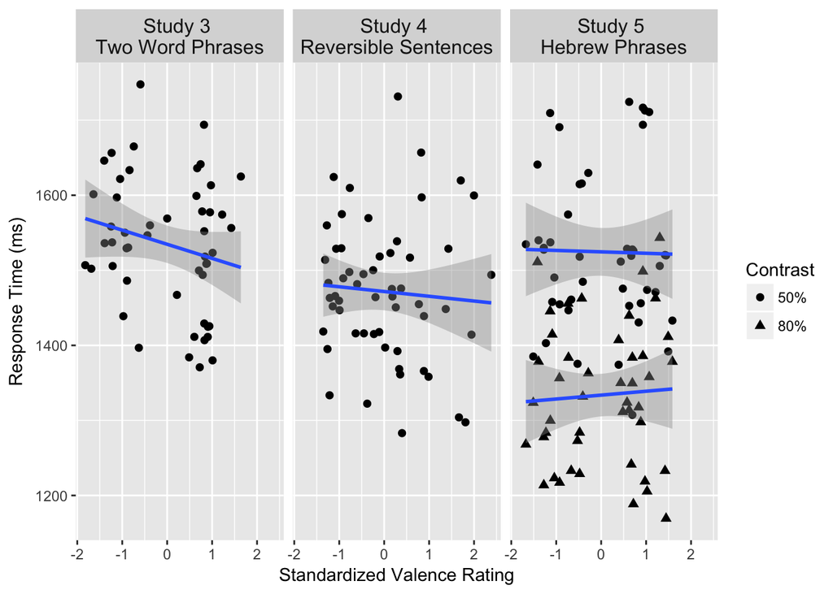

# 4 Experiment 3

In Experiment 3, we used Sklar’s code to replicate Experiments 1 and 2. The experiments were run in an order, such that 1a and 2a were run first (counterbalanced) and 1b and 2b were run second. This, we reasoned, would provide the most likely grounds for Sklar’s results to replicate.

## 4.1 Experiment 3a (Replication of Expt 1a)

### 4.1.1 Raw RTs

Semantics *does* affect raw RTs

```r
# excluded subjects
print(paste("n subj excluded = ",total.n-excl.n))
```

```
## [1] "n subj excluded =  12"
```

```r
# excluded trials
print(paste("% trials excluded = ",((n.trials - n.excl.trials)/n.trials)*100))
```

```
## [1] "% trials excluded =  5.70841239721695"
```

```r
print(paste("median trials excluded per participant = ",median(subj.excl.trials$final_trials), "sd= ", sd(subj.excl.trials$final_trials), "range= ", range(subj.excl.trials$final_trials)))
```

```
## [1] "median trials excluded per participant =  4 sd=  5.93274932409672 range=  0"
## [2] "median trials excluded per participant =  4 sd=  5.93274932409672 range=  27"
```

```r
print(paste("median timeouts per participant = ",median(timeouts$rt), "sd= ", sd(timeouts$rt), "range= ", range(timeouts$rt)))
```

```
## [1] "median timeouts per participant =  0 sd=  9.60269615354213 range=  0"
## [2] "median timeouts per participant =  0 sd=  9.60269615354213 range=  51"
```

```r
sklar.sem$Length <- nchar(as.character(sklar.sem$Stim_column))
sklar.sem$Length  <- (sklar.sem$Length  - mean(sklar.sem$Length,na.rm= T))/sd(sklar.sem$Length,na.rm= T)


sklar.sem.sum <- summaryBy(rt~ SubjNo + Condition, data = sklar.sem, keep.names = T)
kable(summaryBy(rt ~ Condition, data = sklar.sem.sum, FUN = c(mean,sd)),digits=2)
```

| Condition | rt.mean | rt.sd |
| --- | --- | --- |
| Control | 1.83 | 0.66 |
| Violation | 1.91 | 0.78 |

```r
t.test(rt ~ Condition, data = sklar.sem.sum, paired = T)
```

```
##
##  Paired t-test
##
## data:  rt by Condition
## t = -2.4307, df = 61, p-value = 0.01802
## alternative hypothesis: true difference in means is not equal to 0
## 95 percent confidence interval:
##  -0.16068618 -0.01563647
## sample estimates:
## mean of the differences
##             -0.08816132
```

```r
es <- t.test(rt ~ Condition, data = sklar.sem.sum, paired = T)
es.t.test.raw <- rbind(es.t.test.raw,data.frame(t = es$statistic,n1 = es$parameter,n2 = es$parameter,
                                                r = cor.test(subset(sklar.sem.sum, Condition == "Control")$rt,subset(sklar.sem.sum, Condition == "Violation")$rt)$estimate))

# lmer (Rabag style)
sklar.sem.sum.raw <- summary(lmer(rt ~ Condition +Length+ (1+Condition|SubjNo)+ (1|Stim_column), data = sklar.sem))
kable(data.frame(sklar.sem.sum.raw$coefficients, "p value"=2*pnorm(-abs(coef(sklar.sem.sum.raw)[,3]))), digits=2)
```

|  | Estimate | Std..Error | t.value | p.value |
| --- | --- | --- | --- | --- |
| (Intercept) | 1.83 | 0.08 | 21.64 | 0.00 |
| ConditionViolation | 0.08 | 0.04 | 2.29 | 0.02 |
| Length | -0.05 | 0.01 | -3.33 | 0.00 |

```r
#print(paste("p value = ", 2*pnorm(-abs(coef(sklar.sem.sum.raw)[,3]))))
```

### 4.1.2 Log RTs

But there is no effect of semantics for log RTs

```r
sklar.sem$Length <- nchar(as.character(sklar.sem$Stim_column))
sklar.sem$Length  <- (sklar.sem$Length  - mean(sklar.sem$Length,na.rm= T))/sd(sklar.sem$Length,na.rm= T)


sklar.sem.sum <- summaryBy(rt~ SubjNo + Condition, data = sklar.sem, keep.names = T)
kable(summaryBy(rt ~ Condition, data = sklar.sem.sum, FUN = c(mean,sd)), digits=2)
```

| Condition | rt.mean | rt.sd |
| --- | --- | --- |
| Control | 7.39 | 0.36 |
| Violation | 7.41 | 0.40 |

```r
t.test(rt ~ Condition, data = sklar.sem.sum, paired = T)
```

```
##
##  Paired t-test
##
## data:  rt by Condition
## t = -1.697, df = 61, p-value = 0.09479
## alternative hypothesis: true difference in means is not equal to 0
## 95 percent confidence interval:
##  -0.054309947  0.004446126
## sample estimates:
## mean of the differences
##             -0.02493191
```

```r
es <- t.test(rt ~ Condition, data = sklar.sem.sum, paired = T)
es.t.test.log <- rbind(es.t.test.log,data.frame(t = es$statistic,n1 = es$parameter,n2 = es$parameter,
                                                r = cor.test(subset(sklar.sem.sum, Condition == "Control")$rt,subset(sklar.sem.sum, Condition == "Violation")$rt)$estimate))

# lmer (Rabag style)
sklar.sem.sum.log <- summary(lmer(rt ~ Condition +Length+ (1+Condition|SubjNo)+ (1|Stim_column), data = sklar.sem))
kable(data.frame(sklar.sem.sum.log$coefficients, "p value"=2*pnorm(-abs(coef(sklar.sem.sum.log)[,3]))), digits=2)
```

|  | Estimate | Std..Error | t.value | p.value |
| --- | --- | --- | --- | --- |
| (Intercept) | 7.39 | 0.05 | 161.04 | 0.00 |
| ConditionViolation | 0.02 | 0.02 | 1.37 | 0.17 |
| Length | -0.03 | 0.01 | -3.95 | 0.00 |

```r
#print(paste("p value = ", 2*pnorm(-abs(coef(sklar.sem.sum.log)[,3]))))
```

### 4.1.3 Raw RTs (Semantic experiment first)

No effect of semantics on raw RTs

```r
# excluded subjects
print(paste("n subj excluded = ",total.n-excl.n))
```

```
## [1] "n subj excluded =  7"
```

```r
# excluded trials
print(paste("% trials excluded = ",((n.trials - n.excl.trials)/n.trials)*100))
```

```
## [1] "% trials excluded =  6.47058823529412"
```

```r
print(paste("median trials excluded per participant = ",median(subj.excl.trials$final_trials), "sd= ", sd(subj.excl.trials$final_trials), "range= ", range(subj.excl.trials$final_trials)))
```

```
## [1] "median trials excluded per participant =  4.5 sd=  6.0606133751262 range=  0"
## [2] "median trials excluded per participant =  4.5 sd=  6.0606133751262 range=  25"
```

```r
print(paste("median timeouts per participant = ",median(timeouts$rt), "sd= ", sd(timeouts$rt), "range= ", range(timeouts$rt)))
```

```
## [1] "median timeouts per participant =  0 sd=  11.0950033393009 range=  0"
## [2] "median timeouts per participant =  0 sd=  11.0950033393009 range=  51"
```

```r
sklar.sem$Length <- nchar(as.character(sklar.sem$Stim_column))
sklar.sem$Length  <- (sklar.sem$Length  - mean(sklar.sem$Length,na.rm= T))/sd(sklar.sem$Length,na.rm= T)


sklar.sem.sum <- summaryBy(rt~ SubjNo + Condition, data = sklar.sem, keep.names = T)
kable(summaryBy(rt ~ Condition, data = sklar.sem.sum, FUN = c(mean,sd)),digits=2)
```

| Condition | rt.mean | rt.sd |
| --- | --- | --- |
| Control | 1.88 | 0.76 |
| Violation | 1.99 | 0.97 |

```r
t.test(rt ~ Condition, data = sklar.sem.sum, paired = T)
```

```
##
##  Paired t-test
##
## data:  rt by Condition
## t = -1.4659, df = 29, p-value = 0.1534
## alternative hypothesis: true difference in means is not equal to 0
## 95 percent confidence interval:
##  -0.2664751  0.0439700
## sample estimates:
## mean of the differences
##              -0.1112525
```

```r
# lmer (Rabag style)
sklar.sem.sum.raw <- summary(lmer(rt ~ Condition +Length+ (1+Condition|SubjNo)+ (1|Stim_column), data = sklar.sem))
kable(data.frame(sklar.sem.sum.raw$coefficients, "p value"=2*pnorm(-abs(coef(sklar.sem.sum.raw)[,3]))), digits=2)
```

|  | Estimate | Std..Error | t.value | p.value |
| --- | --- | --- | --- | --- |
| (Intercept) | 1.88 | 0.14 | 13.62 | 0.00 |
| ConditionViolation | 0.11 | 0.07 | 1.42 | 0.15 |
| Length | -0.04 | 0.02 | -2.03 | 0.04 |

```r
#print(paste("p value = ", 2*pnorm(-abs(coef(sklar.sem.sum.raw)[,3]))))
```

### 4.1.4 Log RTs (Semantic experiment first)

No effect of semantics for log RTs

```r
sklar.sem$Length <- nchar(as.character(sklar.sem$Stim_column))
sklar.sem$Length  <- (sklar.sem$Length  - mean(sklar.sem$Length,na.rm= T))/sd(sklar.sem$Length,na.rm= T)


sklar.sem.sum <- summaryBy(rt~ SubjNo + Condition, data = sklar.sem, keep.names = T)
kable(summaryBy(rt ~ Condition, data = sklar.sem.sum, FUN = c(mean,sd)), digits=2)
```

| Condition | rt.mean | rt.sd |
| --- | --- | --- |
| Control | 7.39 | 0.38 |
| Violation | 7.42 | 0.43 |

```r
t.test(rt ~ Condition, data = sklar.sem.sum, paired = T)
```

```
##
##  Paired t-test
##
## data:  rt by Condition
## t = -1.1448, df = 29, p-value = 0.2617
## alternative hypothesis: true difference in means is not equal to 0
## 95 percent confidence interval:
##  -0.08347214  0.02356155
## sample estimates:
## mean of the differences
##              -0.0299553
```

```r
# lmer (Rabag style)
sklar.sem.sum.log <- summary(lmer(rt ~ Condition +Length+ (1+Condition|SubjNo)+ (1|Stim_column), data = sklar.sem))
kable(data.frame(sklar.sem.sum.log$coefficients, "p value"=2*pnorm(-abs(coef(sklar.sem.sum.log)[,3]))), digits=2)
```

|  | Estimate | Std..Error | t.value | p.value |
| --- | --- | --- | --- | --- |
| (Intercept) | 7.39 | 0.07 | 106.85 | 0.00 |
| ConditionViolation | 0.03 | 0.03 | 1.03 | 0.30 |
| Length | -0.02 | 0.01 | -1.97 | 0.05 |

```r
#print(paste("p value = ", 2*pnorm(-abs(coef(sklar.sem.sum.log)[,3]))))
```

### 4.1.5 Raw RTs (Emotional experiment first)

No effect of semantics on raw RTs

```r
# excluded subjects
print(paste("n subj excluded = ",total.n-excl.n))
```

```
## [1] "n subj excluded =  5"
```

```r
# excluded trials
print(paste("% trials excluded = ",((n.trials - n.excl.trials)/n.trials)*100))
```

```
## [1] "% trials excluded =  5.02450980392157"
```

```r
print(paste("median trials excluded per participant = ",median(subj.excl.trials$final_trials), "sd= ", sd(subj.excl.trials$final_trials), "range= ", range(subj.excl.trials$final_trials)))
```

```
## [1] "median trials excluded per participant =  3.5 sd=  5.93920815836481 range=  0"
## [2] "median trials excluded per participant =  3.5 sd=  5.93920815836481 range=  26"
```

```r
print(paste("median timeouts per participant = ",median(timeouts$rt), "sd= ", sd(timeouts$rt), "range= ", range(timeouts$rt)))
```

```
## [1] "median timeouts per participant =  0 sd=  7.94727369348503 range=  0"
## [2] "median timeouts per participant =  0 sd=  7.94727369348503 range=  47"
```

```r
sklar.sem$Length <- nchar(as.character(sklar.sem$Stim_column))
sklar.sem$Length  <- (sklar.sem$Length  - mean(sklar.sem$Length,na.rm= T))/sd(sklar.sem$Length,na.rm= T)


sklar.sem.sum <- summaryBy(rt~ SubjNo + Condition, data = sklar.sem, keep.names = T)
kable(summaryBy(rt ~ Condition, data = sklar.sem.sum, FUN = c(mean,sd)),digits=2)
```

| Condition | rt.mean | rt.sd |
| --- | --- | --- |
| Control | 1.78 | 0.59 |
| Violation | 1.83 | 0.61 |

```r
t.test(rt ~ Condition, data = sklar.sem.sum, paired = T)
```

```
##
##  Paired t-test
##
## data:  rt by Condition
## t = -1.6256, df = 31, p-value = 0.1142
## alternative hypothesis: true difference in means is not equal to 0
## 95 percent confidence interval:
##  -0.10549770  0.01191362
## sample estimates:
## mean of the differences
##             -0.04679204
```

```r
# lmer (Rabag style)
sklar.sem.sum.raw <- summary(lmer(rt ~ Condition +Length+ (1+Condition|SubjNo)+ (1|Stim_column), data = sklar.sem))
kable(data.frame(sklar.sem.sum.raw$coefficients, "p value"=2*pnorm(-abs(coef(sklar.sem.sum.raw)[,3]))), digits=2)
```

|  | Estimate | Std..Error | t.value | p.value |
| --- | --- | --- | --- | --- |
| (Intercept) | 1.78 | 0.10 | 17.19 | 0.0 |
| ConditionViolation | 0.04 | 0.03 | 1.28 | 0.2 |
| Length | -0.06 | 0.02 | -3.61 | 0.0 |

```r
#print(paste("p value = ", 2*pnorm(-abs(coef(sklar.sem.sum.raw)[,3]))))
```

### 4.1.6 Log RTs (Emotional experiment first)

No effect of semantics for log RTs

```r
sklar.sem$Length <- nchar(as.character(sklar.sem$Stim_column))
sklar.sem$Length  <- (sklar.sem$Length  - mean(sklar.sem$Length,na.rm= T))/sd(sklar.sem$Length,na.rm= T)


sklar.sem.sum <- summaryBy(rt~ SubjNo + Condition, data = sklar.sem, keep.names = T)
kable(summaryBy(rt ~ Condition, data = sklar.sem.sum, FUN = c(mean,sd)), digits=2)
```

| Condition | rt.mean | rt.sd |
| --- | --- | --- |
| Control | 7.37 | 0.34 |
| Violation | 7.40 | 0.36 |

```r
t.test(rt ~ Condition, data = sklar.sem.sum, paired = T)
```

```
##
##  Paired t-test
##
## data:  rt by Condition
## t = -1.4916, df = 31, p-value = 0.1459
## alternative hypothesis: true difference in means is not equal to 0
## 95 percent confidence interval:
##  -0.056311899  0.008738564
## sample estimates:
## mean of the differences
##             -0.02378667
```

```r
# lmer (Rabag style)
sklar.sem.sum.log <- summary(lmer(rt ~ Condition +Length+ (1+Condition|SubjNo)+ (1|Stim_column), data = sklar.sem))
kable(data.frame(sklar.sem.sum.log$coefficients, "p value"=2*pnorm(-abs(coef(sklar.sem.sum.log)[,3]))), digits=2)
```

|  | Estimate | Std..Error | t.value | p.value |
| --- | --- | --- | --- | --- |
| (Intercept) | 7.38 | 0.06 | 121.90 | 0.00 |
| ConditionViolation | 0.02 | 0.02 | 1.14 | 0.25 |
| Length | -0.03 | 0.01 | -3.99 | 0.00 |

```r
#print(paste("p value = ", 2*pnorm(-abs(coef(sklar.sem.sum.log)[,3]))))
```

## 4.2 Experiment 3b (Replication of Experiment 1b)

### 4.2.1 Raw RTs

Semantics does not affect raw RTs

```r
# excluded subjects
print(paste("n subj excluded = ",total.n-excl.n))
```

```
## [1] "n subj excluded =  8"
```

```r
# excluded trials
print(paste("% trials excluded = ",((n.trials - n.excl.trials)/ n.trials)*100))
```

```
## [1] "% trials excluded =  5.47311827956989"
```

```r
print(paste("median trials excluded per participant = ",median(subj.excl.trials$rt), "sd= ", sd(subj.excl.trials$final_trials), "range= ", range(subj.excl.trials$final_trials)))
```

```
## [1] "median trials excluded per participant =  11 sd=  14.9989599498413 range=  2"
## [2] "median trials excluded per participant =  11 sd=  14.9989599498413 range=  82"
```

```r
print(paste("median timeouts per participant = ",median(timeouts$rt), "sd= ", sd(timeouts$rt), "range= ", range(timeouts$rt)))
```

```
## [1] "median timeouts per participant =  0 sd=  0.491122009440984 range=  0"
## [2] "median timeouts per participant =  0 sd=  0.491122009440984 range=  4"
```

```r
edin.sem$Length <- nchar(as.character(edin.sem$Stim_column))
edin.sem$Length <- (edin.sem$Length - mean(edin.sem$Length))/sd(edin.sem$Length)


# Lin Reg (sklar style)
edin.sem.sum <- summaryBy(rt  ~ SubjNo + Condition, data = edin.sem, keep.names = T)
kable(summaryBy(rt ~ Condition, data = edin.sem.sum, FUN = c(mean,sd)), digits=2)
```

| Condition | rt.mean | rt.sd |
| --- | --- | --- |
| Control | 1.32 | 0.35 |
| Violation | 1.32 | 0.35 |

```r
t.test(rt ~ Condition, data = edin.sem.sum, paired = T)
```

```
##
##  Paired t-test
##
## data:  rt by Condition
## t = 0.091436, df = 61, p-value = 0.9274
## alternative hypothesis: true difference in means is not equal to 0
## 95 percent confidence interval:
##  -0.01571699  0.01722322
## sample estimates:
## mean of the differences
##             0.000753118
```

```r
es <- t.test(rt ~ Condition, data = edin.sem.sum, paired = T)
es.t.test.raw <- rbind(es.t.test.raw,data.frame(t = es$statistic,n1 = es$parameter,n2 = es$parameter,
                                                r = cor.test(subset(edin.sem.sum, Condition == "Control")$rt,subset(edin.sem.sum, Condition == "Violation")$rt)$estimate))

# lmer (Rabag style)
edin.sem.sum.raw <- summary(lmer(rt ~ Condition +Length+ (1+Condition|SubjNo)+ (1|Stim_column), data = edin.sem))
kable(data.frame(edin.sem.sum.raw$coefficients, "p value"=2*pnorm(-abs(coef(edin.sem.sum.raw)[,3]))), digits=2)
```

|  | Estimate | Std..Error | t.value | p.value |
| --- | --- | --- | --- | --- |
| (Intercept) | 1.32 | 0.04 | 30.16 | 0.00 |
| ConditionViolation | 0.00 | 0.01 | -0.11 | 0.91 |
| Length | -0.02 | 0.00 | -5.35 | 0.00 |

```r
#print(paste("p value = ", 2*pnorm(-abs(coef(edin.sem.sum.raw)[,3]))))
```

### 4.2.2 Log RTs

Semantics does not affect log RTs

```r
edin.sem$Length <- nchar(as.character(edin.sem$Stim_column))
edin.sem$Length <- (edin.sem$Length - mean(edin.sem$Length))/sd(edin.sem$Length)


# Lin Reg (sklar style)
edin.sem.sum <- summaryBy(rt  ~ SubjNo + Condition, data = edin.sem, keep.names = T)
kable(summaryBy(rt ~ Condition, data = edin.sem.sum, FUN = c(mean,sd)), digits=2)
```

| Condition | rt.mean | rt.sd |
| --- | --- | --- |
| Control | 7.13 | 0.28 |
| Violation | 7.13 | 0.29 |

```r
t.test(rt ~ Condition, data = edin.sem.sum, paired = T)
```

[output not shown]

```r
es <- t.test(rt ~ Condition, data = edin.sem.sum, paired = T)
es.t.test.log <- rbind(es.t.test.log,data.frame(t = es$statistic,n1 = es$parameter,n2 = es$parameter,
                                                r = cor.test(subset(edin.sem.sum, Condition == "Control")$rt,subset(edin.sem.sum, Condition == "Violation")$rt)$estimate))


# lmer (Rabag style)
edin.sem.sum.log <- summary(lmer(rt ~ Condition +Length+ (1+Condition|SubjNo)+ (1|Stim_column), data = edin.sem))
kable(data.frame(edin.sem.sum.log$coefficients, "p value"=2*pnorm(-abs(coef(edin.sem.sum.log)[,3]))), digits=2)
```

|  | Estimate | Std..Error | t.value | p.value |
| --- | --- | --- | --- | --- |
| (Intercept) | 7.13 | 0.04 | 200.34 | 0.00 |
| ConditionViolation | 0.00 | 0.01 | -0.37 | 0.71 |
| Length | -0.01 | 0.00 | -5.43 | 0.00 |

```r
#print(paste("p value = ", 2*pnorm(-abs(coef(edin.sem.sum.log)[,3]))))
```

## 4.3 Experiment 3c (Replication of Expt 2a)

### 4.3.1 Raw RTs

Emotional semantics does not affect raw RTs

```r
# excluded subjects
print(paste("n subj excluded = ",total.n-excl.n))
```

```
## [1] "n subj excluded =  14"
```

```r
# excluded trials
print(paste("% trials excluded = ",((n.trials - n.excl.trials)/n.trials)*100))
```

```
## [1] "% trials excluded =  4.43333333333333"
```

```r
print(paste("median trials excluded per participant = ",median(subj.excl.trials$rt), "sd= ", sd(subj.excl.trials$final_trials), "range= ", range(subj.excl.trials$final_trials)))
```

```
## [1] "median trials excluded per participant =  2 sd=  2.07561848382488 range=  0"
## [2] "median trials excluded per participant =  2 sd=  2.07561848382488 range=  11"
```

```r
print(paste("median timeouts per participant = ",median(timeouts$rt), "sd= ", sd(timeouts$rt), "range= ", range(timeouts$rt)))
```

```
## [1] "median timeouts per participant =  0 sd=  5.0619267630626 range=  0"
## [2] "median timeouts per participant =  0 sd=  5.0619267630626 range=  26"
```

```r
sklar.emo$Length <- nchar(as.character(sklar.emo$Stim_column))
sklar.emo$Length <- (sklar.emo$Length - mean(sklar.emo$Length))/sd(sklar.emo$Length)


sklar.emo.sum <- summaryBy(rt ~ Stim_column + MeanAffectivity_column, data = sklar.emo, keep.names = T)
sklar.emo.sum.graph <- sklar.emo.sum
print("Linear model")
```

```
## [1] "Linear model"
```

```r
kable(summary(lm(rt ~ MeanAffectivity_column, data = sklar.emo.sum))$coefficients, digits=2)
```

|  | Estimate | Std. Error | t value | Pr(>\|t\|) |
| --- | --- | --- | --- | --- |
| (Intercept) | 1.94 | 0.03 | 75.22 | 0.00 |
| MeanAffectivity_column | 0.02 | 0.03 | 0.88 | 0.38 |

```r
es <- lm(rt~MeanAffectivity_column, data = sklar.emo.sum)
es.t.test.raw <- rbind(es.t.test.raw, data.frame(t = summary(es)$coefficients[2,3],n1 = summary(es)$df[2],
                                                 n2 = summary(es)$df[2], r = 0.5))
# r = 0.5 because this is not a within subjects effect

print("Mixed model")
```

```
## [1] "Mixed model"
```

```r
emo.sklar.lmer.raw <- summary(lmer(rt ~ MeanAffectivity_column +Length+ (1+MeanAffectivity_column|SubjNo)+ (1|Stim_column), data = sklar.emo))
kable(data.frame(emo.sklar.lmer.raw$coefficients, "p value"=2*pnorm(-abs(coef(emo.sklar.lmer.raw)[,3]))), digits =2)
```

|  | Estimate | Std..Error | t.value | p.value |
| --- | --- | --- | --- | --- |
| (Intercept) | 1.97 | 0.12 | 16.53 | 0.0 |
| MeanAffectivity_column | 0.02 | 0.02 | 0.67 | 0.5 |
| Length | -0.09 | 0.02 | -3.93 | 0.0 |

```r
#print(paste("p value = ", 2*pnorm(-abs(coef(emo.sklar.lmer.raw)[2,3]))))
```

### 4.3.2 Log RTs

Emotional semantics does not affect log RTs

```r
sklar.emo$Length <- nchar(as.character(sklar.emo$Stim_column))
sklar.emo$Length <- (sklar.emo$Length - mean(sklar.emo$Length))/sd(sklar.emo$Length)


sklar.emo.sum <- summaryBy(rt ~ Stim_column + MeanAffectivity_column, data = sklar.emo, keep.names = T)
print("Linear model")
```

```
## [1] "Linear model"
```

```r
kable(summary(lm(rt ~ MeanAffectivity_column, data = sklar.emo.sum))$coefficients, digits =2)
```

|  | Estimate | Std. Error | t value | Pr(>\|t\|) |
| --- | --- | --- | --- | --- |
| (Intercept) | 0.48 | 0.01 | 45.14 | 0.00 |
| MeanAffectivity_column | 0.01 | 0.01 | 0.83 | 0.41 |

```r
es <- lm(rt~MeanAffectivity_column, data = sklar.emo.sum)
es.t.test.log <- rbind(es.t.test.log, data.frame(t = summary(es)$coefficients[2,3],n1 = summary(es)$df[2],n2 = summary(es)$df[2], r = 0.5))


print("Mixed model")
```

```
## [1] "Mixed model"
```

```r
emo.sklar.lmer.log <- summary(lmer(rt ~ MeanAffectivity_column+Length + (1+MeanAffectivity_column|SubjNo)+ (1|Stim_column), data = sklar.emo))
kable(data.frame(emo.sklar.lmer.log$coefficients, "p value"= 2*pnorm(-abs(coef(emo.sklar.lmer.log)[,3]))), digits=2)
```

|  | Estimate | Std..Error | t.value | p.value |
| --- | --- | --- | --- | --- |
| (Intercept) | 0.49 | 0.05 | 9.67 | 0.00 |
| MeanAffectivity_column | 0.01 | 0.01 | 0.54 | 0.59 |
| Length | -0.04 | 0.01 | -4.79 | 0.00 |

```r
#print(paste("p value = ", 2*pnorm(-abs(coef(emo.sklar.lmer.log)[2,3]))))
```

### 4.3.3 Raw RTs (semantic first)

Emotional semantics does not affect raw RTs

```r
# excluded subjects
print(paste("n subj excluded = ",total.n-excl.n))
```

```
## [1] "n subj excluded =  6"
```

```r
# excluded trials
print(paste("% trials excluded = ",((n.trials - n.excl.trials)/n.trials)*100))
```

```
## [1] "% trials excluded =  3.80645161290323"
```

```r
print(paste("median trials excluded per participant = ",median(subj.excl.trials$rt), "sd= ", sd(subj.excl.trials$final_trials), "range= ", range(subj.excl.trials$final_trials)))
```

```
## [1] "median trials excluded per participant =  2 sd=  1.37489002492751 range=  0"
## [2] "median trials excluded per participant =  2 sd=  1.37489002492751 range=  5"
```

```r
print(paste("median timeouts per participant = ",median(timeouts$rt), "sd= ", sd(timeouts$rt), "range= ", range(timeouts$rt)))
```

```
## [1] "median timeouts per participant =  0 sd=  5.83828618565291 range=  0"
## [2] "median timeouts per participant =  0 sd=  5.83828618565291 range=  26"
```

```r
sklar.emo$Length <- nchar(as.character(sklar.emo$Stim_column))
sklar.emo$Length <- (sklar.emo$Length - mean(sklar.emo$Length))/sd(sklar.emo$Length)


sklar.emo.sum <- summaryBy(rt ~ Stim_column + MeanAffectivity_column, data = sklar.emo, keep.names = T)
sklar.emo.sum.graph <- sklar.emo.sum
print("Linear model")
```

```
## [1] "Linear model"
```

```r
kable(summary(lm(rt ~ MeanAffectivity_column, data = sklar.emo.sum))$coefficients, digits=2)
```

|  | Estimate | Std. Error | t value | Pr(>\|t\|) |
| --- | --- | --- | --- | --- |
| (Intercept) | 1.82 | 0.03 | 60.70 | 0.0 |
| MeanAffectivity_column | 0.01 | 0.03 | 0.39 | 0.7 |

```r
print("Mixed model")
```

```
## [1] "Mixed model"
```

```r
emo.sklar.lmer.raw <- summary(lmer(rt ~ MeanAffectivity_column +Length+ (1+MeanAffectivity_column|SubjNo)+ (1|Stim_column), data = sklar.emo))
kable(data.frame(emo.sklar.lmer.raw$coefficients, "p value"=2*pnorm(-abs(coef(emo.sklar.lmer.raw)[,3]))), digits =2)
```

|  | Estimate | Std..Error | t.value | p.value |
| --- | --- | --- | --- | --- |
| (Intercept) | 1.83 | 0.14 | 12.75 | 0.00 |
| MeanAffectivity_column | 0.01 | 0.03 | 0.31 | 0.75 |
| Length | -0.06 | 0.03 | -2.12 | 0.03 |

```r
#print(paste("p value = ", 2*pnorm(-abs(coef(emo.sklar.lmer.raw)[2,3]))))
```

### 4.3.4 Log RTs (Semantic first)

Emotional semantics does not affect log RTs

```r
sklar.emo$Length <- nchar(as.character(sklar.emo$Stim_column))
sklar.emo$Length <- (sklar.emo$Length - mean(sklar.emo$Length))/sd(sklar.emo$Length)


sklar.emo.sum <- summaryBy(rt ~ Stim_column + MeanAffectivity_column, data = sklar.emo, keep.names = T)
print("Linear model")
```

```
## [1] "Linear model"
```

```r
kable(summary(lm(rt ~ MeanAffectivity_column, data = sklar.emo.sum))$coefficients, digits =2)
```

|  | Estimate | Std. Error | t value | Pr(>\|t\|) |
| --- | --- | --- | --- | --- |
| (Intercept) | 0.43 | 0.01 | 31.64 | 0.00 |
| MeanAffectivity_column | 0.01 | 0.01 | 0.69 | 0.49 |

```r
print("Mixed model")
```

```
## [1] "Mixed model"
```

```r
emo.sklar.lmer.log <- summary(lmer(rt ~ MeanAffectivity_column+Length + (1+MeanAffectivity_column|SubjNo)+ (1|Stim_column), data = sklar.emo))
kable(data.frame(emo.sklar.lmer.log$coefficients, "p value"= 2*pnorm(-abs(coef(emo.sklar.lmer.log)[,3]))), digits=2)
```

|  | Estimate | Std..Error | t.value | p.value |
| --- | --- | --- | --- | --- |
| (Intercept) | 0.43 | 0.07 | 6.49 | 0.00 |
| MeanAffectivity_column | 0.01 | 0.01 | 0.49 | 0.62 |
| Length | -0.04 | 0.01 | -3.07 | 0.00 |

```r
#print(paste("p value = ", 2*pnorm(-abs(coef(emo.sklar.lmer.log)[2,3]))))
```

### 4.3.5 Raw RTs (Emotional first)

Emotional semantics does not affect raw RTs

```r
# excluded subjects
print(paste("n subj excluded = ",total.n-excl.n))
```

```
## [1] "n subj excluded =  8"
```

```r
# excluded trials
print(paste("% trials excluded = ",((n.trials - n.excl.trials)/n.trials)*100))
```

```
## [1] "% trials excluded =  5.10344827586207"
```

```r
print(paste("median trials excluded per participant = ",median(subj.excl.trials$rt), "sd= ", sd(subj.excl.trials$final_trials), "range= ", range(subj.excl.trials$final_trials)))
```

```
## [1] "median trials excluded per participant =  2 sd=  2.61296502213416 range=  0"
## [2] "median trials excluded per participant =  2 sd=  2.61296502213416 range=  11"
```

```r
print(paste("median timeouts per participant = ",median(timeouts$rt), "sd= ", sd(timeouts$rt), "range= ", range(timeouts$rt)))
```

```
## [1] "median timeouts per participant =  0 sd=  4.22686247308407 range=  0"
## [2] "median timeouts per participant =  0 sd=  4.22686247308407 range=  22"
```

```r
sklar.emo$Length <- nchar(as.character(sklar.emo$Stim_column))
sklar.emo$Length <- (sklar.emo$Length - mean(sklar.emo$Length))/sd(sklar.emo$Length)


sklar.emo.sum <- summaryBy(rt ~ Stim_column + MeanAffectivity_column, data = sklar.emo, keep.names = T)
sklar.emo.sum.graph <- sklar.emo.sum
print("Linear model")
```

```
## [1] "Linear model"
```

```r
kable(summary(lm(rt ~ MeanAffectivity_column, data = sklar.emo.sum))$coefficients, digits=2)
```

|  | Estimate | Std. Error | t value | Pr(>\|t\|) |
| --- | --- | --- | --- | --- |
| (Intercept) | 2.08 | 0.04 | 51.37 | 0.00 |
| MeanAffectivity_column | 0.03 | 0.04 | 0.84 | 0.41 |

```r
print("Mixed model")
```

```
## [1] "Mixed model"
```

```r
emo.sklar.lmer.raw <- summary(lmer(rt ~ MeanAffectivity_column +Length+ (1+MeanAffectivity_column|SubjNo)+ (1|Stim_column), data = sklar.emo))
kable(data.frame(emo.sklar.lmer.raw$coefficients, "p value"=2*pnorm(-abs(coef(emo.sklar.lmer.raw)[,3]))), digits =2)
```

|  | Estimate | Std..Error | t.value | p.value |
| --- | --- | --- | --- | --- |
| (Intercept) | 2.11 | 0.19 | 11.00 | 0.00 |
| MeanAffectivity_column | 0.03 | 0.04 | 0.57 | 0.57 |
| Length | -0.11 | 0.04 | -3.17 | 0.00 |

```r
#print(paste("p value = ", 2*pnorm(-abs(coef(emo.sklar.lmer.raw)[2,3]))))
```

### 4.3.6 Log RTs (Emotional first)

Emotional semantics does not affect log RTs

```r
sklar.emo$Length <- nchar(as.character(sklar.emo$Stim_column))
sklar.emo$Length <- (sklar.emo$Length - mean(sklar.emo$Length))/sd(sklar.emo$Length)


sklar.emo.sum <- summaryBy(rt ~ Stim_column + MeanAffectivity_column, data = sklar.emo, keep.names = T)
print("Linear model")
```

```
## [1] "Linear model"
```

```r
kable(summary(lm(rt ~ MeanAffectivity_column, data = sklar.emo.sum))$coefficients, digits =2)
```

|  | Estimate | Std. Error | t value | Pr(>\|t\|) |
| --- | --- | --- | --- | --- |
| (Intercept) | 0.54 | 0.01 | 35.93 | 0.0 |
| MeanAffectivity_column | 0.01 | 0.02 | 0.52 | 0.6 |

```r
print("Mixed model")
```

```
## [1] "Mixed model"
```

```r
emo.sklar.lmer.log <- summary(lmer(rt ~ MeanAffectivity_column+Length + (1+MeanAffectivity_column|SubjNo)+ (1|Stim_column), data = sklar.emo))
kable(data.frame(emo.sklar.lmer.log$coefficients, "p value"= 2*pnorm(-abs(coef(emo.sklar.lmer.log)[,3]))), digits=2)
```

|  | Estimate | Std..Error | t.value | p.value |
| --- | --- | --- | --- | --- |
| (Intercept) | 0.55 | 0.08 | 7.21 | 0.00 |
| MeanAffectivity_column | 0.00 | 0.02 | 0.28 | 0.78 |
| Length | -0.05 | 0.01 | -3.45 | 0.00 |

```r
#print(paste("p value = ", 2*pnorm(-abs(coef(emo.sklar.lmer.log)[2,3]))))
```

## 4.4 Experiment 3d (Replication of Experiment 2b)

### 4.4.1 Raw RTs

Emotional semantics marginally affects raw RTs

```r
# excluded subjects
print(paste("n subj excluded = ",total.n-excl.n))
```

```
## [1] "n subj excluded =  8"
```

```r
# excluded trials
print(paste("% trials excluded = ",((n.trials - n.excl.trials)/n.trials)*100))
```

```
## [1] "% trials excluded =  4.04211956521739"
```

```r
print(paste("median trials excluded per participant = ",median(subj.excl.trials$rt), "sd= ", sd(subj.excl.trials$final_trials), "range= ", range(subj.excl.trials$final_trials)))
```

```
## [1] "median trials excluded per participant =  1 sd=  1.57225131780807 range=  0"
## [2] "median trials excluded per participant =  1 sd=  1.57225131780807 range=  10"
```

```r
print(paste("median timeouts per participant = ",median(timeouts$rt), "sd= ", sd(timeouts$rt), "range= ", range(timeouts$rt)))
```

```
## [1] "median timeouts per participant =  0 sd=  2.00581119755833 range=  0"
## [2] "median timeouts per participant =  0 sd=  2.00581119755833 range=  16"
```

```r
edin.emo$Length <- nchar(as.character(edin.emo$Stim_column))
edin.emo$Length <- (edin.emo$Length - mean(edin.emo$Length, na.rm = T))/sd(edin.emo$Length)


# Lin Reg (sklar style)
edin.emo.sum.factorial <- summaryBy(rt  ~ SubjNo + Type_column, data = edin.emo, keep.names = T)
#t.test(rt ~ Type_column, data = edin.emo.sum.factorial, paired = T)


#es <- t.test(rt ~ Type_column, data = edin.emo.sum.factorial, paired = T)
#es.t.test.raw <- rbind(es.t.test.raw,data.frame(t = es$statistic,n1 = es$parameter,n2 = es$parameter))


edin.emo.sum <- summaryBy(rt  ~ Stim_column + MeanAffectivity_column, data = edin.emo, keep.names = T)
edin.emo.sum.graph <- edin.emo.sum
print("Linear model")
```

```
## [1] "Linear model"
```

```r
kable(summary(lm(rt ~ MeanAffectivity_column, data = edin.emo.sum))$coefficients, digits =2)
```

|  | Estimate | Std. Error | t value | Pr(>\|t\|) |
| --- | --- | --- | --- | --- |
| (Intercept) | 1.43 | 0.01 | 101.33 | 0.00 |
| MeanAffectivity_column | 0.03 | 0.01 | 2.35 | 0.02 |

```r
es <- lm(rt~MeanAffectivity_column, data = edin.emo.sum)
es.t.test.raw <- rbind(es.t.test.raw, data.frame(t = summary(es)$coefficients[2,3],n1 = summary(es)$df[2],
                                                 n2 = summary(es)$df[2], r = 0.5))
# r = 0.5 because this is not a within subject effect

# lmer (Rabag style)
print("Mixed model")
```

```
## [1] "Mixed model"
```

```r
edin.emo.sum.raw <- summary(lmer(rt ~ Type_column +Length+ (1+Type_column|SubjNo)+ (1|Stim_column), data = edin.emo))
kable(data.frame(edin.emo.sum.raw$coefficients, "p value"=2*pnorm(-abs(coef(edin.emo.sum.raw)[,3]))), digits=2)
```

|  | Estimate | Std..Error | t.value | p.value |
| --- | --- | --- | --- | --- |
| (Intercept) | 1.41 | 0.06 | 24.55 | 0.00 |
| Type_columnNeutral sentence | 0.06 | 0.03 | 1.83 | 0.07 |
| Length | -0.03 | 0.01 | -1.74 | 0.08 |

```r
#print(paste("p value = ", 2*pnorm(-abs(coef(edin.emo.sum.raw)[,3]))))
```

### 4.4.2 Log RTs

Emotional semantics does not affect log RTs

```r
edin.emo$Length <- nchar(as.character(edin.emo$Stim_column))
edin.emo$Length <- (edin.emo$Length - mean(edin.emo$Length, na.rm = T))/sd(edin.emo$Length)


# Lin Reg (sklar style)
edin.emo.sum.factorial <- summaryBy(rt  ~ SubjNo + Type_column, data = edin.emo, keep.names = T)
# t.test(rt ~ Type_column, data = edin.emo.sum.factorial, paired = T)
#
#
# es <- t.test(rt ~ Type_column, data = edin.emo.sum.factorial, paired = T)
# es.t.test.log <- rbind(es.t.test.log,data.frame(t = es$statistic,n1 = es$parameter,n2 = es$parameter))


edin.emo.sum <- summaryBy(rt  ~ Stim_column + MeanAffectivity_column, data = edin.emo, keep.names = T)

print("Linear model")
```

```
## [1] "Linear model"
```

```r
kable(summary(lm(rt ~ MeanAffectivity_column, data = edin.emo.sum))$coefficients, digits=2)
```

|  | Estimate | Std. Error | t value | Pr(>\|t\|) |
| --- | --- | --- | --- | --- |
| (Intercept) | 0.24 | 0.01 | 29.58 | 0.0 |
| MeanAffectivity_column | 0.01 | 0.01 | 0.86 | 0.4 |

```r
es <- lm(rt~MeanAffectivity_column, data = edin.emo.sum)
es.t.test.log <- rbind(es.t.test.log, data.frame(t = summary(es)$coefficients[2,3],n1 = summary(es)$df[2],n2 = summary(es)$df[2], r = 0.5))

print("Mixed model")
```

```
## [1] "Mixed model"
```

```r
# lmer (Rabag style)
edin.emo.sum.log <- summary(lmer(rt ~ Type_column +Length+ (1+Type_column|SubjNo)+ (1|Stim_column), data = edin.emo))
kable(data.frame(edin.emo.sum.log$coefficients, "p value"=2*pnorm(-abs(coef(edin.emo.sum.log)[,3]))), digits=2)
```

|  | Estimate | Std..Error | t.value | p.value |
| --- | --- | --- | --- | --- |
| (Intercept) | 0.24 | 0.04 | 6.39 | 0.00 |
| Type_columnNeutral sentence | 0.01 | 0.02 | 0.61 | 0.54 |
| Length | -0.02 | 0.01 | -2.98 | 0.00 |

```r
#print(paste("p value = ", 2*pnorm(-abs(coef(edin.emo.sum.log)[,3]))))
```

## 4.5 Graphs

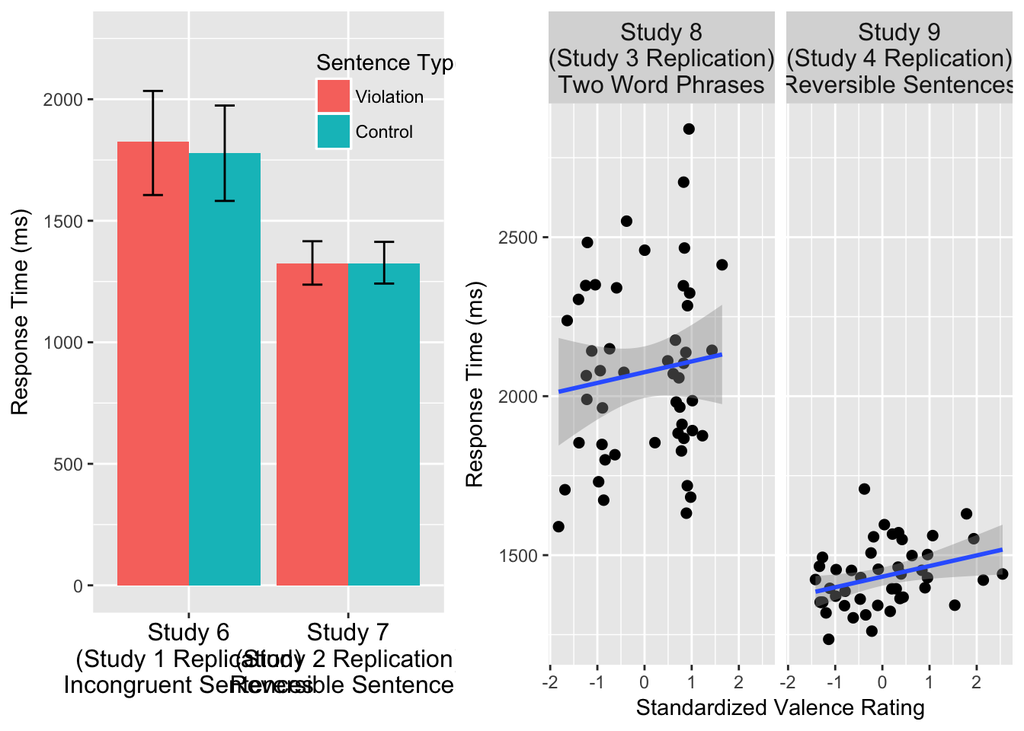

# 5 Experiment 4

In this experiment, we attempt to replicate Yang & Yeh (2011)’s finding that emotional/neutral words break suppression at different times. Such an effect here, might suggest that participants couldn’t combine word meanings because they could not visually resolve them. In our replication, participants saw 300 words, in a 2*2 design that crossed Emotional Content (Negative vs Neutral words) and Length (Short vs Long words). Emotional ratings were taken from the Florida Affective Norms for English Words. We have a smaller number of subjects than our other experiments (28 total, 26 after exclusions), because participants saw many more critical trials than most comparable experiments.

## 5.1 Raw RTs

No effect of semantics on raw RTs (but effect of length)

```
## [1] "n subj excluded =  2"
```

```
## [1] "% trials excluded =  0.92"
```

```
## [1] "median trials excluded per participant =  3.5 sd=  1.74223552236333 range=  0"
## [2] "median trials excluded per participant =  3.5 sd=  1.74223552236333 range=  6"
```

```
## [1] "median timeouts per participant =  0 sd=  30.0534796689442 range=  0"
## [2] "median timeouts per participant =  0 sd=  30.0534796689442 range=  137"
```

```
## [1] "RTs against length"
```

| length | rt * 1000.mean | rt * 1000.sd |
| --- | --- | --- |
| Long | 1307.37 | 584.26 |
| Short | 1476.10 | 614.66 |

```
## [1] "RTs against semantics"
```

| prime_semantics | rt * 1000.mean | rt * 1000.sd |
| --- | --- | --- |
| negative | 1371.90 | 588.70 |
| neutral | 1411.57 | 621.54 |

```
## [1] "RTs against length by semantics"
```

| prime_semantics | rt * 1000.mean | rt * 1000.sd |
| --- | --- | --- |
| negative | 1371.90 | 588.70 |
| neutral | 1411.57 | 621.54 |

|  | Estimate | Std..Error | t.value | p.values |
| --- | --- | --- | --- | --- |
| (Intercept) | 1.28 | 0.11 | 11.66 | 0.00 |
| prime_semanticsneutral | 0.04 | 0.04 | 1.22 | 0.22 |
| lengthShort | 0.18 | 0.04 | 4.00 | 0.00 |
| prime_semanticsneutral:lengthShort | -0.01 | 0.05 | -0.20 | 0.84 |

## 5.2 Log RTs

No effect of semantics on Log RTs (but effect of length)

```
## [1] "RTs against length"
```

| length | rt * 1000.mean | rt * 1000.sd |
| --- | --- | --- |
| Long | 1307.37 | 584.26 |
| Short | 1476.10 | 614.66 |

```
## [1] "RTs against semantics"
```

| prime_semantics | rt * 1000.mean | rt * 1000.sd |
| --- | --- | --- |
| negative | 1371.90 | 588.70 |
| neutral | 1411.57 | 621.54 |

```
## [1] "RTs against length by semantics"
```

| prime_semantics | rt * 1000.mean | rt * 1000.sd |
| --- | --- | --- |
| negative | 1371.90 | 588.70 |
| neutral | 1411.57 | 621.54 |

|  | Estimate | Std..Error | t.value | p.values |
| --- | --- | --- | --- | --- |
| (Intercept) | 7.00 | 0.07 | 102.62 | 0.00 |
| prime_semanticsneutral | 0.02 | 0.02 | 0.98 | 0.33 |
| lengthShort | 0.11 | 0.02 | 5.80 | 0.00 |
| prime_semanticsneutral:lengthShort | 0.00 | 0.02 | -0.01 | 1.00 |

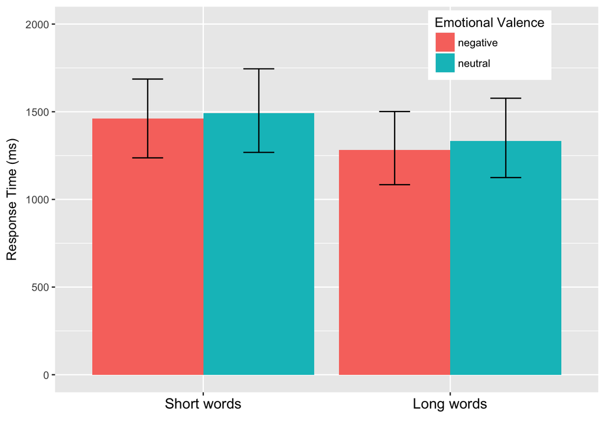

# 6 Meta analysis

```r
library(BayesFactor)


print("Raw effect sizes")
```

```
## [1] "Raw effect sizes"
```

```r
# Add t.tests from Sklar Experiments (n =4), yang yeh experiments (n=2)
# Because I am uncertain about d from partial eta squared (there's some debate about this)
# we first transform F to t (t = sqrt(F))
# and then calculate as with all the others, assuming a correlation of about 0.95
# For Expt 1, F = 20.09, t = -4.48 (make -ve to account for directionality)
# For Expt 2, F = 18.35, t = -4.28
es.t.test.raw <- rbind(es.t.test.raw, data.frame(t = c(2.63,2.92,2.523,2.229,-4.48,-4.28), n1 = c(31,21,45,45,11,11), n2 = c(31,21,45,45,11,11), r = c(0.975,0.975,0.5,0.5,0.975,0.975)))
es.t.test.raw
```

```
##              t n1 n2         r
## t  -1.78737755 47 47 0.9742224
## t1 -0.02216960 47 47 0.9913647
## 1  -1.50963114 48 48 0.0000000
## 11 -0.50561703 54 54 0.0000000
## t2 -2.43074544 61 61 0.9354318
## t3  0.09143552 61 61 0.9830299
## 12  0.87912326 48 48 0.0000000
## 13  2.35280120 44 44 0.0000000
## t4  1.47879051 25 25 0.9622294
## t5  0.94848740 25 25 0.9675652
## 14  2.63000000 31 31 0.9750000
## 2   2.92000000 21 21 0.9750000
## 3   2.52300000 45 45 0.5000000
## 4   2.22900000 45 45 0.5000000
## 5  -4.48000000 11 11 0.9750000
## 6  -4.28000000 11 11 0.9750000
```

```r
raw.es <- tes(es.t.test.raw[,1],es.t.test.raw[,2],es.t.test.raw[,3], verbose = FALSE)
raw.es$exp <- c("Study 1", "Study 2","Study 3", "Study 4","Study 6","Study 7","Study 8","Study 9","Study 10a","Study 10b", "Sklar et al. Expt. 1","Sklar et al. Expt. 2", "Sklar et al. Expt. 4a","Sklar et al. Expt. 4b", "Yang & Yeh Expt. 1","Yang & Yeh Expt. 2")
raw.es$lab <- c(rep("Ed",10),rep("Israel",4),rep("Taiwan",2))
raw.es$session <- c("1","1","2","2","3","3","3","3","4","4","5","6","7","8","9","10")
raw.es$procedure <- c("1","2","3","4","1","3","2","4","5","5","1","1","3","3","5","5")
raw.es$r <- es.t.test.raw$r
raw.es$t <- es.t.test.raw$t

# Recalculate d using correlations between conditions for within subjects comparisons
#  (i.e., Experiments 1a and 1b, Experiments 3a and 3b, and the two conditions of Experiment 4, plus
# Estimate the correlations for the Sklar and Yang & Yeh data)

raw.es$d <- raw.es$t * sqrt(2*(1-raw.es$r)/raw.es$n.1)
raw.es$d.se <- sqrt((2 * (1 - raw.es$r)/raw.es$n.1) +
                      (raw.es$d^2)/(2 * raw.es$n.1))

#raw.es
# we originally ran a random effects meta analysis on unadjusted t's,
# but then realised that over-estimated effect size! Now, we adjust for
# correlations so need to use a different metaregression structure
#ran.ef.raw <- rma(d,var.d,random = ~ 1|lab,data = raw.es)
ran.ef.raw <- rma.mv(d,V= (d.se)^2, random = ~ 1|lab,data = raw.es)
ran.ef.raw
```

```
##
## Multivariate Meta-Analysis Model (k = 16; method: REML)
##
## Variance Components:
##
##             estim    sqrt  nlvls  fixed  factor
## sigma^2    0.0449  0.2118      3     no     lab
##
## Test for Heterogeneity:
## Q(df = 15) = 64.5814, p-val < .0001
##
## Model Results:
##
## estimate       se     zval     pval    ci.lb    ci.ub
##  -0.0487   0.1246  -0.3903   0.6963  -0.2930   0.1957
##
## ---
## Signif. codes:  0 '***' 0.001 '**' 0.01 '*' 0.05 '.' 0.1 ' ' 1
```

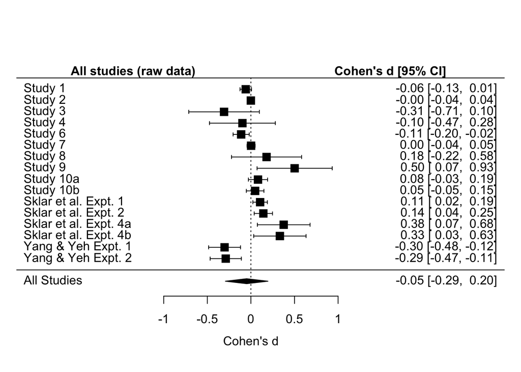

```r
forest(ran.ef.raw,
       slab = raw.es$exp,
       mlab = "All Studies",
       xlab = "Cohen's d", psize = 1.5)
par(font = 2)
text(-1.35, 17.55, "All studies (raw data)")
text(1.6, 17.55, "Cohen's d [95% CI]")
```

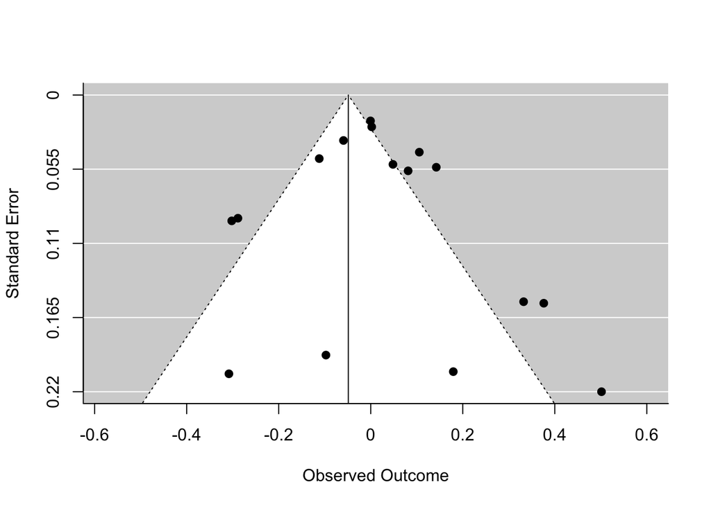

```r
par(font = 1)
funnel(ran.ef.raw)
```

We then calculated a Bayes factor for this regression, comparing a null hypothesis to a hypothesis within which the true effect of unconscious semantics was uniformly distributed somewhere between -1 and 1, i.e., a very non-informative theory which could account for the wide variety in effect sizes found in this literature. The calculator at [Zoltan Dienes’ site](http://www.lifesci.sussex.ac.uk/home/Zoltan_Dienes/inference/Bayes.htm) produced a Bayes factor of 0.24, suggesting that the data is approximately four times more likely under the null hypothesis than the non-informative theory.

We also used Richard Morey’s method for calculating meta-analytic BayesFactors. This function takes t scores and computes effect sizes from them, to produce a meta-analytic Bayes factor. But it assumes that the t scores are from between-subjects t tests, so we first use our effect size estimates to generate the t scores that would have been expected from our effect sizes if our tests had been between-subjects.

```r
raw.es$t_adjusted = raw.es$d * sqrt(raw.es$n.1)
#raw.es
summary(meta.ttestBF(t = raw.es$t_adjusted,n1=raw.es$n.1,n2=raw.es$n.2,nullInterval = c(-1,1)))
```

```
## Bayes factor analysis
## --------------
## [1] Alt., r=0.707 -1<d<1    : 0.2689236    ±0%
## [2] Alt., r=0.707 !(-1<d<1) : 5.709114e-60 ±32.61%
##
## Against denominator:
##   Null, d = 0
## ---
## Bayes factor type: BFmetat, JZS
```

```r
summary(meta.ttestBF(t = raw.es$t_adjusted,n1=raw.es$n.1,n2=raw.es$n.2))
```

```
## Bayes factor analysis
## --------------
## [1] Alt., r=0.707 : 0.1635522 ±0.05%
##
## Against denominator:
##   Null, d = 0
## ---
## Bayes factor type: BFmetat, JZS
```

```r
print("log effect sizes")
```

```
## [1] "log effect sizes"
```

```r
#No longer need to add Expt 4 manually
#es.t.test.log <- rbind(es.t.test.log, data.frame(t = c(1.23,1.21), n1 = c(25,25), n2 = c(25,25)))
#es.t.test.log
log.es <- tes(es.t.test.log[,1],es.t.test.log[,2],es.t.test.log[,3], verbose = FALSE)
log.es$exp <- c("Study 1", "Study 2","Study 3", "Study 4","Study 6","Study 7","Study 8","Study 9","Study 10a","Study 10b")
log.es$lab <- c(rep("Ed",10))#,rep("Israel",4))
log.es$procedure <- c("1","2","3","4","1","3","2","4","5","5")
#kable(log.es)
log.es$r <- es.t.test.log$r
log.es$t <- es.t.test.log$t

log.es$d <- log.es$t * sqrt(2*(1-log.es$r)/log.es$n.1)
log.es$d.se <- sqrt((2 * (1 - log.es$r)/log.es$n.1) +
                      (log.es$d^2)/(2 * log.es$n.1))
#log.es
# Old style analysis before accounting for correlations
#ran.ef.log <- rma(d,var.d,random = ~ 1|procedure, data = log.es)
ran.ef.log <- rma.mv(d,V= (d.se)^2, random = ~ 1|procedure,data = log.es)
ran.ef.log
```

```
##
## Multivariate Meta-Analysis Model (k = 10; method: REML)
##
## Variance Components:
##
##             estim    sqrt  nlvls  fixed     factor
## sigma^2    0.0007  0.0264      5     no  procedure
##
## Test for Heterogeneity:
## Q(df = 9) = 10.9540, p-val = 0.2789
##
## Model Results:
##
## estimate       se     zval     pval    ci.lb    ci.ub
##  -0.0049   0.0177  -0.2744   0.7838  -0.0395   0.0298
##
## ---
## Signif. codes:  0 '***' 0.001 '**' 0.01 '*' 0.05 '.' 0.1 ' ' 1
```

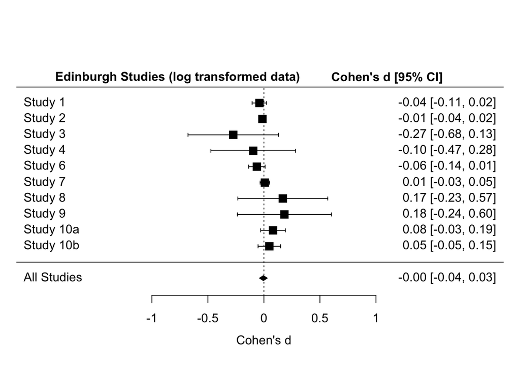

```r
forest(ran.ef.log,
       slab = log.es$exp,
       mlab = "All Studies",
       xlab = "Cohen's d", psize = 1.5)
par(font = 2)
text(-.77, 11.6, "Edinburgh Studies (log transformed data)")
text(1.1, 11.6, "Cohen's d [95% CI]")
```

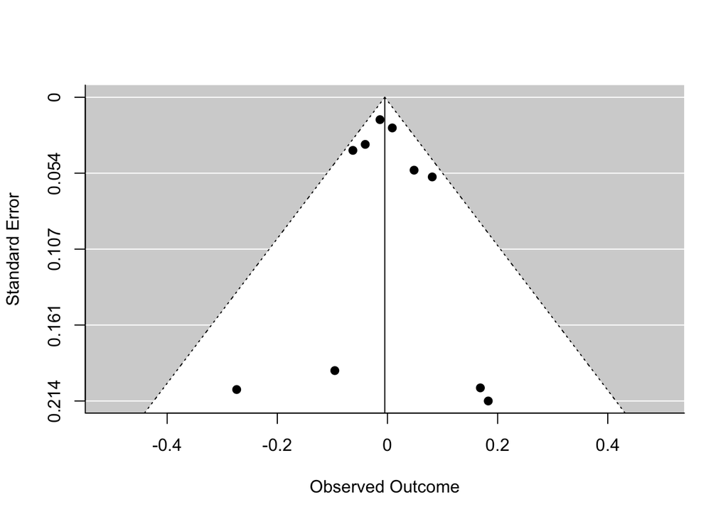

```r
funnel(ran.ef.log)
```

We then calculated a Bayes factor for this regression, comparing a null hypothesis to a hypothesis within which the true effect of unconscious semantics was uniformly distributed somewhere between -1 and 1, i.e., a very non-informative theory which could account for the wide variety in effect sizes found in this literature. The calculator at [Zoltan Dienes’ site](http://www.lifesci.sussex.ac.uk/home/Zoltan_Dienes/inference/Bayes.htm) produced a Bayes factor of 0.02, suggesting that the data is approximately 50 times more likely under the null hypothesis than the non-informative theory.

We also used Richard Morey’s method for calculating meta-analytic BayesFactors

```r
log.es$t_adjusted = log.es$d * sqrt(log.es$n.1)
#log.es

summary(meta.ttestBF(t = log.es$t_adjusted,n1=log.es$n.1,n2=log.es$n.2,nullInterval = c(-1,1)))
```

```
## Bayes factor analysis
## --------------
## [1] Alt., r=0.707 -1<d<1    : 0.1240557   ±0%
## [2] Alt., r=0.707 !(-1<d<1) : 4.77828e-52 ±81.16%
##
## Against denominator:
##   Null, d = 0
## ---
## Bayes factor type: BFmetat, JZS
```

# 7 Summary

Over these experiments, when we analyzed raw RT, we found suggestive evidence (p < .1) for an effect of semantics 4 times out of 9 experiments, although only one of these comparisons was reliable.

- Raw RTs
  - Expt 1a (opposite direction from original finding).
  - Expt 2a (opposite direction from original finding).
  - Expt 3a (1a replication, opposite direction from original finding)
  - Expt 3d (2b replication)

When we analyzed log transformed RTs, we found hints of evidence (p <.1) for an effect of semantics 2 times out of 9 experiments, but none of these comparisons was reliable.

- log RTs
  - Expt 2a (opposite direction from original finding)
  - Expt 3a (1a replication [ish])